#### **Федеральное государственное автономное образовательное учреждение высшего**

#### **профессионального образования**

### **Национальный исследовательский университет**

### **“Высшая школа экономики”**

#### **Факультет экономических наук**

#### **Образовательная программа Экономика и статистика**

## **Компьютерная работа 2**

*Студентов группы БСТ213*

Курченко М. А., Леготкина Е. Р., Куклина Э. О.,

Яргина К. В., Киренкина В. Ю., Борисова П. П.

Москва, 2023 г.

### **Выделение главных компонент**

Рассмотрим применение метода главных компонент: В случаях высокой дисперсии признаков можно применять логарифмирование или другие стандартизации данных для стабилизации разброса признаков и линеаризации парных связей. Это приближает эмпирическое распределение к нормальному, что позволяет использовать тесты для проверки адекватности выборки применению методов компонентного анализа.

В нашем случае используем простейшую нормировку данных:

```r
df2 <- df1[c(1, 2, 3, 4, 5, 6, 7, 8, 9, 10)]
df_new <- scale(df2)
```

Предварительный визуальный анализ распределений:

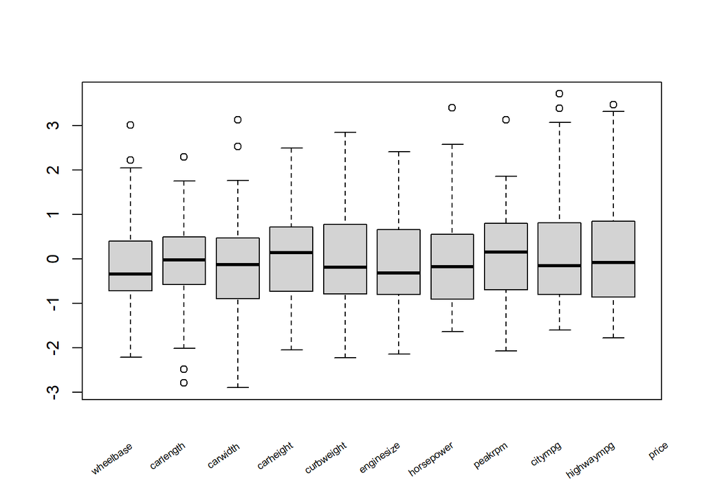

```r
boxplot(df_new, xaxt = "n", cex.lab = 0.7)
text(x =  seq_along(names(df)), y = par("usr")[3] - 1, srt = 35, adj = 1,
     labels = names(df), xpd = TRUE, cex = 0.6)
```

Теперь все данные между собой масштабированы. Выбросы не удаляем, они не мешают построению МГК модели. Построим корреляционную матрицу чтобы проверить мультиколлинеарность: Снижение размерности будет достигаться, если признаки, описывающие совокупность, достаточно коррелированы между собой.

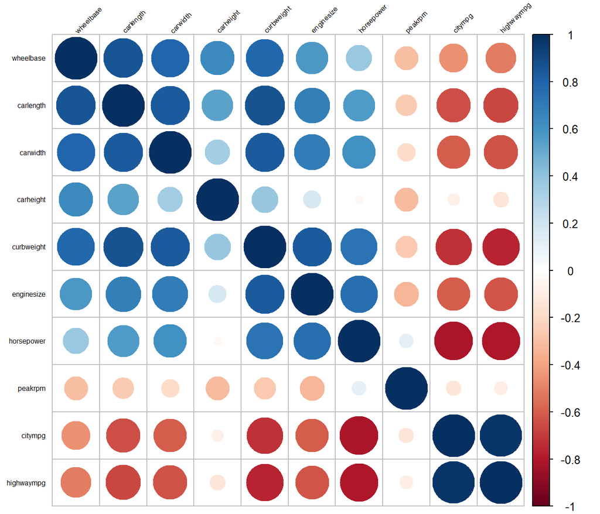

```r
corrplot(cor(df_new), type = "full", method = "circle", tl.col = "black", tl.srt = 45, tl.cex = 0.5)
```

Видим, что есть признаки с сильной корреляцией, вероятно, эти переменные и необходимо объединить. Но мы не можем только по корреляционной матрице сделать вывод о возможности использования МГК.

Применим **тест сферичности Бартлетта**, который используется для оценки эффективности методов снижения размерности. Данный тест проверяет нулевую гипотезу о том, что теоретическая корреляционная матрица многомерного распределения вектора случайных величин, является единичной матрицей. Если нулевая гипотеза отвергается, предпосылки применения метода главных компонента будут выполнены.

```r
bart_spher(df_new)
```

```
##  Bartlett's Test of Sphericity
##
## Call: bart_spher(x = df_new)
##
##      X2 = 2319.857
##      df = 45
## p-value < 2.22e-16
```

Значение p-value проведенного теста **значительно** меньше уровня значимости в 5%. Нулевая гипотеза отвергается, **применение МГК обосновано**.

Перейдем к самому методу главных компонент. Определим главные компоненты:

```r
pc <- PCA(df_new, graph = FALSE)
```

#### **1.1. Вывод о числе главных компонент, которые необходимо оставить для дальнейшего анализа**

1. Выбрать те главные компоненты, которым соответствует собственное значение > 1 (*метод Кайзера*).

```r
pander(pc$eig)
```

|  | eigenvalue | percentage of variance | cumulative percentage of variance |
| --- | --- | --- | --- |
| **comp 1** | 6.086 | 60.86 | 60.86 |
| **comp 2** | 1.855 | 18.55 | 79.41 |
| **comp 3** | 0.8759 | 8.759 | 88.17 |
| **comp 4** | 0.4238 | 4.238 | 92.41 |
| **comp 5** | 0.309 | 3.09 | 95.5 |
| **comp 6** | 0.1344 | 1.344 | 96.84 |
| **comp 7** | 0.1131 | 1.131 | 97.97 |
| **comp 8** | 0.1028 | 1.028 | 99 |
| **comp 9** | 0.07723 | 0.7723 | 99.77 |
| **comp 10** | 0.02265 | 0.2265 | 100 |

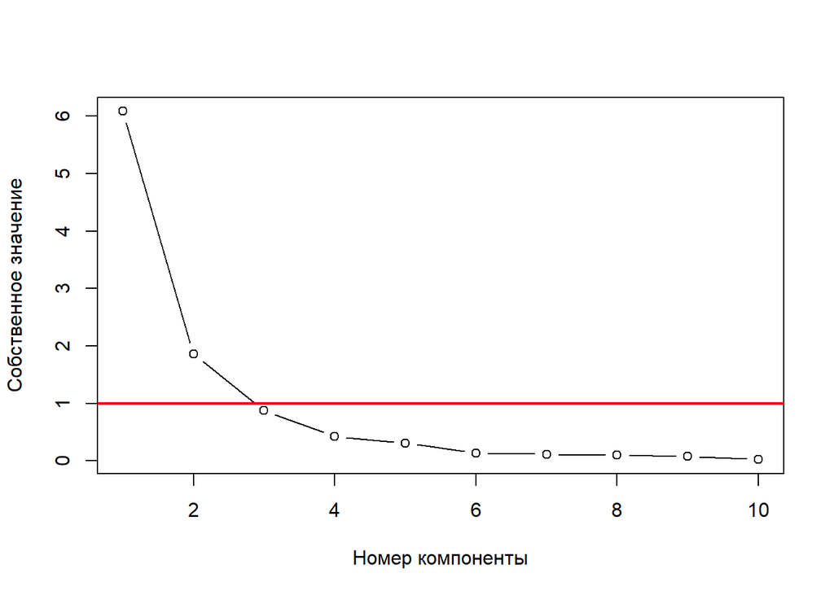

```r
plot(eigen(cor(df_new))$values, bstick = TRUE, type = 'b', main = '', xlab = 'Номер компоненты',
     ylab = 'Собственное значение')
abline(h = 1, col = 'red', lwd = 2)
text(x = 13, y = 1.2, 'eigen value = 1', col = 'red')
```

В этом случае у нас выделяется 2 компоненты.

2. Оптимальное число определяется в соответствии с **долей суммарной вариации** исходных признаков, которую требуется сохранить (обычно 70-80%).

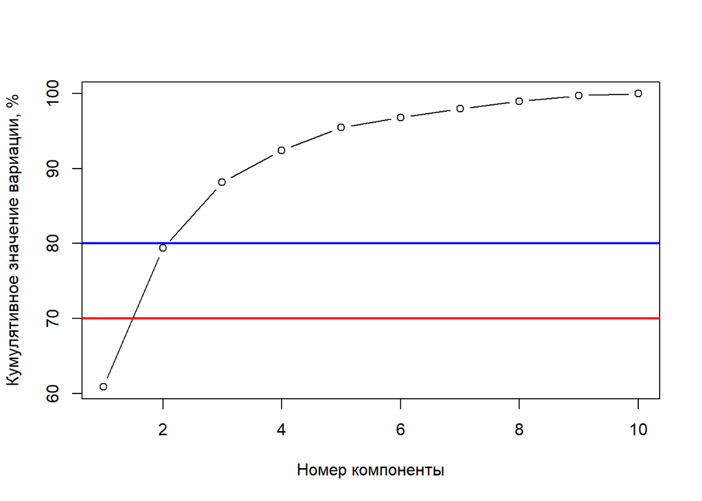

```r
princomp <- princomp(df_new, cor = TRUE)
cumvarsum <- cumsum(princomp$sdev^2 / sum(princomp$sdev^2))*100
plot(cumvarsum, bstick = TRUE, type = 'b', main = '', xlab = 'Номер компоненты',
     ylab = 'Кумулятивное значение вариации, %')
abline(h = 70, col = 'red', lwd = 2)
abline(h = 80, col = 'blue', lwd = 2)
text(x = 13, y = 75, '70%', col = 'red')
text(x = 13, y = 85, '80%', col = 'blue')
```

Аналогично и в этом тесте: 2 компоненты.

3. На основе анализа “графика каменистой осыпи” (выбрать такое число компонент, после которого происходит резкое падение доли сохраненной дисперсии):

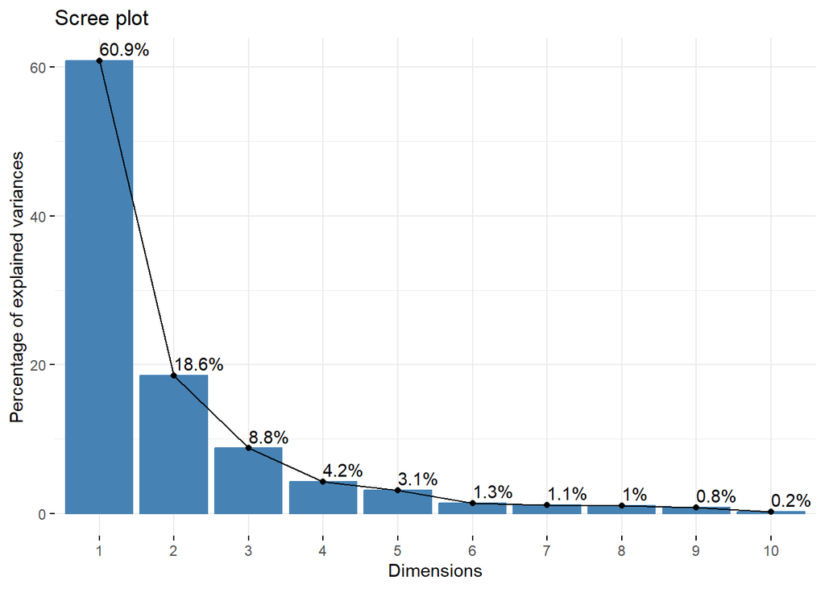

```r
fviz_eig(pc, addlabels = TRUE)
```

Этот график показывает 1 компоненту(но 1 компоненту мы оставить не можем).

Вероятно, необходимо взять 2 компоненты, так как два теста показали их, а также 5 переменных (wheelbase, carlength, carwidth, carheight, curbweight) связаны с размером автомобиля, а остальные 5 (enginesize, horsepower, peakrpm, highwaympg, citympg) связаны с мощностью двигателя.

#### **1.2. - 1.3. Описание суммарного вклада первых главных компонент. Построение графика накопленного вклада главных компонент в суммарную дисперсию исходного признакового пространства**

Собственные значения и доля суммарной вариации исходного набора признаков, приходящаяся на главные компоненты:

```r
pander(pc$eig)
```

|  | eigenvalue | percentage of variance | cumulative percentage of variance |
| --- | --- | --- | --- |
| **comp 1** | 6.086 | 60.86 | 60.86 |
| **comp 2** | 1.855 | 18.55 | 79.41 |
| **comp 3** | 0.8759 | 8.759 | 88.17 |
| **comp 4** | 0.4238 | 4.238 | 92.41 |
| **comp 5** | 0.309 | 3.09 | 95.5 |
| **comp 6** | 0.1344 | 1.344 | 96.84 |
| **comp 7** | 0.1131 | 1.131 | 97.97 |
| **comp 8** | 0.1028 | 1.028 | 99 |
| **comp 9** | 0.07723 | 0.7723 | 99.77 |
| **comp 10** | 0.02265 | 0.2265 | 100 |

Можно также воспользоваться иной функцией – *princomp* пакета *stats*:

```r
princomp <- princomp(df_new, cor = TRUE) # если не указать cor, то будет использоваться ковариационная матрица
summary(princomp)
```

```
## Importance of components:
##                           Comp.1    Comp.2     Comp.3     Comp.4     Comp.5
## Standard deviation     2.4669682 1.3620061 0.93592026 0.65100085 0.55590982
## Proportion of Variance 0.6085932 0.1855061 0.08759467 0.04238021 0.03090357
## Cumulative Proportion  0.6085932 0.7940993 0.88169396 0.92407417 0.95497775
##                            Comp.6     Comp.7     Comp.8      Comp.9     Comp.10
## Standard deviation     0.36664634 0.33634941 0.32059502 0.277910499 0.150488097
## Proportion of Variance 0.01344295 0.01131309 0.01027812 0.007723425 0.002264667
## Cumulative Proportion  0.96842070 0.97973379 0.99001191 0.997735333 1.000000000
```

```r
pander(princomp$loadings[,1:6])
```

|  | Comp.1 | Comp.2 | Comp.3 | Comp.4 | Comp.5 | Comp.6 |
| --- | --- | --- | --- | --- | --- | --- |
| **wheelbase** | 0.3288 | 0.3162 | 0.2276 | 0.2464 | 0.1799 | 0.4783 |
| **carlength** | 0.3695 | 0.1696 | 0.1406 | 0.1029 | 0.1301 | 0.341 |
| **carwidth** | 0.3564 | 0.08373 | 0.02748 | 0.5458 | 0.2591 | -0.6927 |
| **carheight** | 0.1621 | 0.5133 | 0.481 | -0.4038 | -0.4616 | -0.315 |
| **curbweight** | 0.3894 | 0.04535 | -0.08739 | 0.04651 | -0.08853 | 0.09338 |
| **enginesize** | 0.34 | -0.02082 | -0.4441 | 0.09359 | -0.4945 | 0.171 |
| **horsepower** | 0.3184 | -0.3659 | -0.1612 | 0.005165 | -0.4171 | -0.1358 |
| **peakrpm** | -0.08109 | -0.5092 | 0.6635 | 0.3691 | -0.3026 | 0.1275 |
| **citympg** | -0.3318 | 0.3393 | -0.1057 | 0.3992 | -0.2784 | 0.0463 |
| **highwaympg** | -0.3419 | 0.2998 | -0.1185 | 0.4016 | -0.2742 | 0.03167 |

Эти методы выдают такие же значения.

Теперь посмотрим на график накопленного вклада главных компонент в суммарную дисперсию исходного признакового пространства. Он визуализирует накопленную дисперсию каждой компоненты. График также подтверждает мысль о том, что первые две компоненты вносят наибольший вклад в суммарную дисперсию. Именно поэтому мы приняли решение оставить для дальнейшего анализа две главные компоненты.

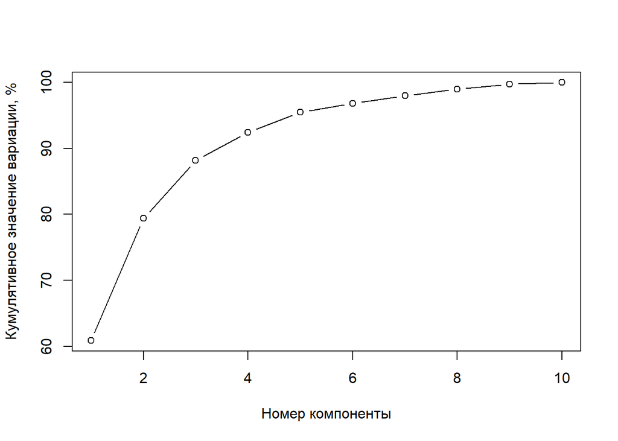

```r
cumvarsum <- cumsum(princomp$sdev^2 / sum(princomp$sdev^2))*100
plot(cumvarsum, bstick = TRUE, type = 'b', main = '', xlab = 'Номер компоненты',
     ylab = 'Кумулятивное значение вариации, %')
```

Убедимся, что главные компоненты линейно независимы:

```r
pander(cor.test(princomp$scores[,1], princomp$scores[,2]))
```

Pearson’s product-moment correlation: `princomp$scores[, 1]` and `princomp$scores[, 2]`

| Test statistic | df | P value | Alternative hypothesis | cor |
| --- | --- | --- | --- | --- |
| -2.441e-14 | 188 | 1 | two.sided | -1.78e-15 |

```r
pander(cor.test(princomp$scores[,1], princomp$scores[,3]))
```

Pearson’s product-moment correlation: `princomp$scores[, 1]` and `princomp$scores[, 3]`

| Test statistic | df | P value | Alternative hypothesis | cor |
| --- | --- | --- | --- | --- |
| -1.179e-14 | 188 | 1 | two.sided | -8.601e-16 |

```r
pander(cor.test(princomp$scores[,1], princomp$scores[,4]))
```

Pearson’s product-moment correlation: `princomp$scores[, 1]` and `princomp$scores[, 4]`

| Test statistic | df | P value | Alternative hypothesis | cor |
| --- | --- | --- | --- | --- |
| -6.404e-16 | 188 | 1 | two.sided | -4.671e-17 |

```r
pander(cor.test(princomp$scores[,1], princomp$scores[,5]))
```

Pearson’s product-moment correlation: `princomp$scores[, 1]` and `princomp$scores[, 5]`

| Test statistic | df | P value | Alternative hypothesis | cor |
| --- | --- | --- | --- | --- |
| 1.425e-16 | 188 | 1 | two.sided | 1.039e-17 |

```r
pander(cor.test(princomp$scores[,1], princomp$scores[,6]))
```

Pearson’s product-moment correlation: `princomp$scores[, 1]` and `princomp$scores[, 6]`

| Test statistic | df | P value | Alternative hypothesis | cor |
| --- | --- | --- | --- | --- |
| 8.376e-15 | 188 | 1 | two.sided | 6.109e-16 |

```r
pander(cor.test(princomp$scores[,2], princomp$scores[,3]))
```

Pearson’s product-moment correlation: `princomp$scores[, 2]` and `princomp$scores[, 3]`

| Test statistic | df | P value | Alternative hypothesis | cor |
| --- | --- | --- | --- | --- |
| 1.487e-14 | 188 | 1 | two.sided | 1.084e-15 |

```r
pander(cor.test(princomp$scores[,2], princomp$scores[,4]))
```

Pearson’s product-moment correlation: `princomp$scores[, 2]` and `princomp$scores[, 4]`

| Test statistic | df | P value | Alternative hypothesis | cor |
| --- | --- | --- | --- | --- |
| 4.643e-15 | 188 | 1 | two.sided | 3.386e-16 |

```r
pander(cor.test(princomp$scores[,2], princomp$scores[,5]))
```

Pearson’s product-moment correlation: `princomp$scores[, 2]` and `princomp$scores[, 5]`

| Test statistic | df | P value | Alternative hypothesis | cor |
| --- | --- | --- | --- | --- |
| 5.885e-15 | 188 | 1 | two.sided | 4.292e-16 |

```r
pander(cor.test(princomp$scores[,2], princomp$scores[,6]))
```

Pearson’s product-moment correlation: `princomp$scores[, 2]` and `princomp$scores[, 6]`

| Test statistic | df | P value | Alternative hypothesis | cor |
| --- | --- | --- | --- | --- |
| 2.132e-14 | 188 | 1 | two.sided | 1.555e-15 |

```r
pander(cor.test(princomp$scores[,3], princomp$scores[,4]))
```

Pearson’s product-moment correlation: `princomp$scores[, 3]` and `princomp$scores[, 4]`

| Test statistic | df | P value | Alternative hypothesis | cor |
| --- | --- | --- | --- | --- |
| 9.867e-15 | 188 | 1 | two.sided | 7.196e-16 |

```r
pander(cor.test(princomp$scores[,4], princomp$scores[,5]))
```

Pearson’s product-moment correlation: `princomp$scores[, 4]` and `princomp$scores[, 5]`

| Test statistic | df | P value | Alternative hypothesis | cor |
| --- | --- | --- | --- | --- |
| 4.156e-16 | 188 | 1 | two.sided | 3.031e-17 |

```r
pander(cor.test(princomp$scores[,4], princomp$scores[,6]))
```

Pearson’s product-moment correlation: `princomp$scores[, 4]` and `princomp$scores[, 6]`

| Test statistic | df | P value | Alternative hypothesis | cor |
| --- | --- | --- | --- | --- |
| 2.598e-14 | 188 | 1 | two.sided | 1.895e-15 |

```r
pander(cor.test(princomp$scores[,5], princomp$scores[,6]))
```

Pearson’s product-moment correlation: `princomp$scores[, 5]` and `princomp$scores[, 6]`

| Test statistic | df | P value | Alternative hypothesis | cor |
| --- | --- | --- | --- | --- |
| 2.286e-14 | 188 | 1 | two.sided | 1.667e-15 |

Для всех пар мы получили очень маленькие значения коэффициента корреляции. Следовательно, главные компоненты попарно линейно независимы.

#### **1.4. Интерпретация главных компонент на основе анализа матрицы факторных нагрузок. Дать названия выделенным главным компонентам**

Мы все-таки предполагаем 2 главных компоненты. Отобразим матрицу факторных нагрузок:

```r
pca <- principal(cor(df_new), nfactors = 2, rotate = "none", covar = FALSE)

pca_loadings <- matrix(as.numeric(pca$loadings), ncol = 2, nrow = ncol(df_new))
rownames(pca_loadings) <- colnames(df_new)

kbl(round(pca_loadings, 3),
    caption = "Таблица 1. Матрица факторных нагрузок",
    booktabs = T, col.names = c("PC1", "PC2")) %>%
    kable_classic(html_font = "Cambria", font_size = 12, full_width = F)
```

Таблица 1. Матрица факторных нагрузок

|  | PC1 | PC2 |
| --- | --- | --- |
| wheelbase | 0.811 | 0.431 |
| carlength | 0.911 | 0.231 |
| carwidth | 0.879 | 0.114 |
| carheight | 0.400 | 0.699 |
| curbweight | 0.961 | 0.062 |
| enginesize | 0.839 | -0.028 |
| horsepower | 0.786 | -0.498 |
| peakrpm | -0.200 | -0.694 |
| citympg | -0.818 | 0.462 |
| highwaympg | -0.843 | 0.408 |

Проанализируем матрицу факторных нагрузок. Факторные нагрузки - это корреляция переменных с выделенным фактором. Чем больше величина факторной нагрузки, тем сильнее связь этой переменной с фактором. В матрице факторных нагрузок наибольшие значения для компоненты 1 принимают её факторные нагрузки с carlength, carwidth, curbweight, enginesize.

Теперь посмотрим на вторую компоненту. Для неё мы получили наибольшие значения факторных нагрузок по переменным: carheight, horsepower, peakrpm, citympg, highwaympg.

Мы видим, что самую сильную связь с первой компонентой имеют переменные, связанные с габаритами машины и размерами двигателя. Со второй компонентой имеют наибольшую связь величины, характеризующие скорость автомобиля и связанное с этим потребление топлива ( за исключением высоты машины). Поэтому мы приняли решение назвать наши компоненты следующим образом:

1. 1 компонента – компонента “массо-габаритные характеристики”
2. 2 компонента – компонента “показатели скорости и потребления топлива”

### **Построение уравнения регрессии с использованием выделенных ГК**

#### **2.1. Построение линейного уравнения регрессии на ГК**

У нас получилось 2 главные компоненты, следовательно на них и строим регрессию:

```r
PC_selected <- pc$ind$coord[, 1:2]
PC_regression <- lm(df1$price ~ PC_selected)
summary(PC_regression)
```

```
##
## Call:
## lm(formula = df1$price ~ PC_selected)
##
## Residuals:
##    Min     1Q Median     3Q    Max
##  -5808  -1728   -345   1068   8957
##
## Coefficients:
##                  Estimate Std. Error t value Pr(>|t|)
## (Intercept)      11509.40     189.19  60.836   <2e-16 ***
## PC_selectedDim.1  1709.62      76.69  22.293   <2e-16 ***
## PC_selectedDim.2  -200.17     138.90  -1.441    0.151
## ---
## Signif. codes:  0 '***' 0.001 '**' 0.01 '*' 0.05 '.' 0.1 ' ' 1
##
## Residual standard error: 2608 on 187 degrees of freedom
## Multiple R-squared:  0.7274, Adjusted R-squared:  0.7245
## F-statistic: 249.5 on 2 and 187 DF,  p-value: < 2.2e-16
```

Получаем, что одна из компонент значима (p-value<0,05), однако вторая компонента незначима (p-value = 0.151 > 0,05), это может быть связано с мультиколлинеарностью. Получили $R^2 = 0.73$, значит 73% вариации можно объяснить нашей моделью.

Само уравнение регрессии тоже значимо, p-value < 0,05

Уравнение:
$$price_i = 11509.40 +
1709.62*component1_i - 200.17 * component2_i +
\varepsilon_i$$

*component1 - компонента “массо-габаритные характеристики”  
*component2 - компонента “показатели скорости и потребления топлива”

#### **2.2. Сопоставление свойств ранее полученных уравнений регрессии (линейное и нелинейное уравнения регрессии) с уравнением регрессии на ГК**

В первой части компьютерной работы мы выбрали **линейное** уравнение:
$$y_i=−52048.412+5.732∗curbweight_i+39.750∗horsepower_i+746.198∗carwidth_i$$
$$−76.670∗carlength_i+99.215∗wheelbase_i+\varepsilon_i$$

**Нелинейное** уравнение:
$$ln(y_i)=−15,8265+3,0329∗ln(carwidth_i)+1,3681∗ln(curbweight_i)+0,4119∗ln(horsepower_i))$$
$$−0,1565∗ln(enginesize_i)+0.4887∗ln(highwaympg_i)−0.3306∗ln(citympg_i)+\epsilon_i$$

Уравнение регрессии на ГК:
$$price =
11509.40 + 1709.62*co mponent1 - 200.17 * component2
+\epsilon_i$$

*Сравнение:*

|  | Значимость компонент | $R^2$ | **Adjusted** $R^2$ |
| --- | --- | --- | --- |
| Линейная регрессия | $\checkmark$ (4/5) | 0.7769 | 0.7708 |
| Нелинейная регрессия | $\checkmark$ (3/6) | 0.8301 | 0.8245 |
| Регрессия на ГК | $\checkmark$ (1/2) | 0.7274 | 0.7245 |

#### 2.3. **Выбор и обоснование лучшего уравнения**

Для выбора лучшего уравнения нужно провести сравнение. Однако, для линейной, нелинейной регрессии и регрессии на главные компоненты мы имеем разную целевую переменную: у линейной регрессии и у регрессии на ГК - `y`, у нелинейной регрессии - `ln(y)`. Поэтому мы не можем проводить сравнение с нелинейной регрессией.

Проведем сравнение между линейной регрессией и регрессией на ГК на основе значений информационных критериев (они основаны на значении функции правдоподобия и штрафуют модель за излишнюю сложность). Поэтому найдем значение критериев Акаике и Шварца для наших моделей.

```r
# Возьмем линейное уравнение из 1 компьютерной работы
lm5 <- lm(price ~ curbweight + horsepower + carwidth + carlength + wheelbase, data = df1)
```

```r
IC_table <- data.frame(n = c('lm5', 'PC_regression'),
                  a = rbind(AIC(lm5), AIC(PC_regression)),
                  b = rbind(BIC(lm5), BIC(PC_regression)))
# информационный критерий Акаике
kbl(IC_table,
    caption = "Таблица 1. Информационные критерии Акаике и Шварца (Баесовский инф. критерий)",
    booktabs = T, col.names = c("Модель", "Значение AIC", "Значение BIC")) %>%
    kable_classic(html_font = "Cambria", font_size = 12, full_width = F)
```

Таблица 1. Информационные критерии Акаике и Шварца (Баесовский инф. критерий)

| Модель | Значение AIC | Значение BIC |
| --- | --- | --- |
| lm5 | 3501.291 | 3524.021 |
| PC_regression | 3533.349 | 3546.337 |

Мы видим, что для линейной модели и AIC, и BIC незначительно меньше, чем для регрессии на ГК. Следовательно, мы делаем выбор в пользу линейной модели с 5 регрессорами. Но нельзя забывать, что мы не рассматриваем нелинейную модель, которая может оказаться лучше.

### **Кластерный анализ**

Перед проведением кластеризации выделим 4 наблюдения из датафрейма, чтобы потом использовать их в дискриминантном анализе

```r
set.seed(1)
rand_df <- df1[sample(nrow(df1), size= 4), ]
paged_table(rand_df)
```

|  | wheelbase | carlength | carwidth | carheight | curbweight | enginesize | horsepower | peakrpm | citympg | highwaympg | price |
| --- | --- | --- | --- | --- | --- | --- | --- | --- | --- | --- | --- |
| 79 | 93.7 | 157.3 | 64.4 | 50.8 | 2004 | 92 | 68 | 5500 | 31 | 38 | 6669 |
| 182 | 104.5 | 187.8 | 66.5 | 54.1 | 3151 | 161 | 156 | 5200 | 19 | 24 | 15750 |
| 144 | 97.2 | 172.0 | 65.4 | 52.5 | 2340 | 108 | 94 | 5200 | 26 | 32 | 9960 |
| 177 | 102.4 | 175.6 | 66.5 | 54.9 | 2414 | 122 | 92 | 4200 | 27 | 32 | 10898 |

Удалим эти наблюдения из основного датафрейма

```r
df2 <- df1[-c(79, 182, 144, 177), -c(11)]
```

Также перед применением кластерного анализа рекомендуется стандартизировать признаки, что мы и делаем с помощью функции `scale()`.

Отбор классифицирующих признаков:

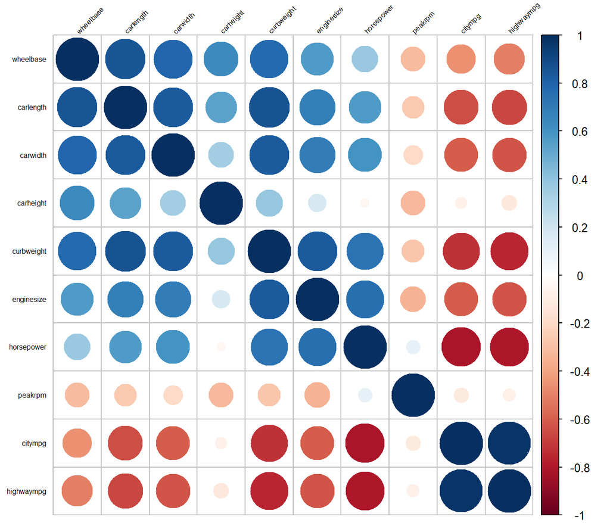

```r
corrplot(cor(scale(df2)), type = "full", method = "circle", tl.col = "black", tl.srt = 45, tl.cex = 0.5)
```

В данном случае мы не будем исключать переменные, так как у нас итак относительно маленькое количество переменных, многие из которых сильно коррелируют между собой. Так как применение евклидовой метрики предпочтительнее в случае слабо коррелированных признаков для кластеризации, то **мы будем использовать расстояние Махаланобиса**, которое является более предпочтительным вариантом при сильной коррелированности.

```r
cluster_df <- as.data.frame(scale(df2))
```

Однако, чтобы использовать расстояние Махаланобиса нам нужно знать параметр k (количество кластеров), чтобы подставить в функцию `cutree()`, иначе разбиения не получится. Для определения количества кластеров воспользуемся 3 методами:

1. **Метод локтя (elbow method)**

Принято считать оптимальным число кластеров, после которого убывание WSS начинает замедляться, т.е. точка изгиба. В нашем случае это 2 кластера.

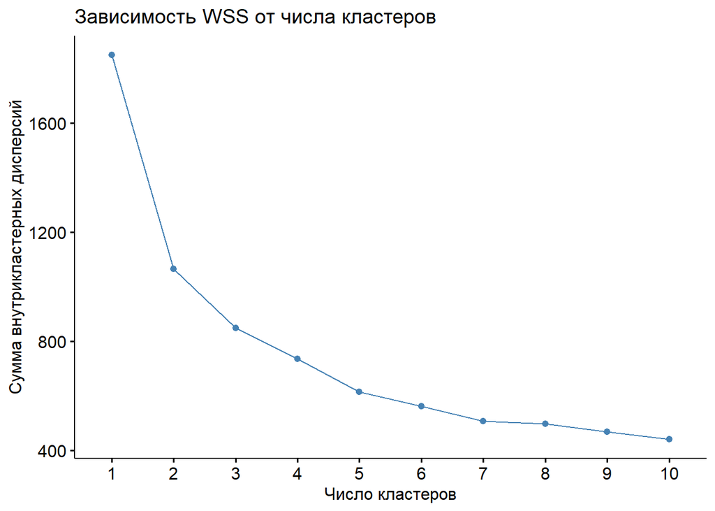

```r
fviz_nbclust(cluster_df, kmeans, method = 'wss') +
labs(x = 'Число кластеров', y = 'Сумма внутрикластерных дисперсий',
           title = 'Зависимость WSS от числа кластеров')
```

2. **Метод силуэтов.** Согласно методу силуэтов: находим точку, которая имеет самый высокий пик, на такое количество кластеров нужно разбивать, в данном случае также 2 кластера.

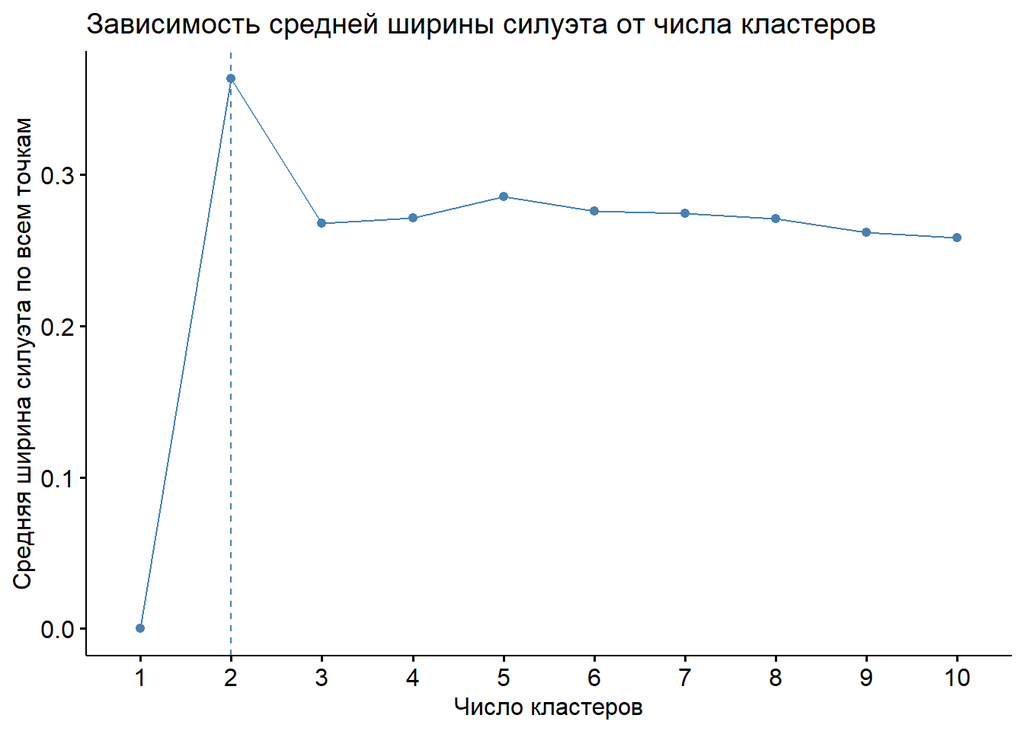

```r
fviz_nbclust(cluster_df, kmeans, method = 'silhouette') +
  labs(x = 'Число кластеров', y = 'Средняя ширина силуэта по всем точкам',
       title = 'Зависимость средней ширины силуэта от числа кластеров')
```

3. **Статистика разрыва (Gap-статистика).** Согласно этой статистике рассчитывается разрыв между кластерами, считается статистика. Смотрим, есть ли различие. Когда мы получаем, что следующая точка меньше предыдущей, то останавливаемся. В данном случае останавливаемся на 1 кластере.

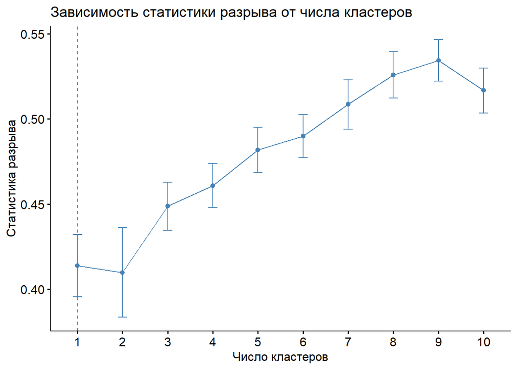

```r
fviz_nbclust(cluster_df, kmeans, method = 'gap_stat') +
  labs(x = 'Число кластеров', y = 'Статистика разрыва',
       title = 'Зависимость статистики разрыва от числа кластеров')
```

По итогу всех трех методов выбираем оптимальное число кластеров (на наш взгляд) - **2.** Но также можем рассмотреть вариант с разбиением на 3 кластера, возможно это даст лучше результаты.

Итак, рассмотрим различные принципы определения расстояния между кластерами.

#### **3.1. Метод Варда**

Данный метод, как правило, дает наиболее удачное разбиение, основан на минимизации суммы внутрикластерных дисперсий.

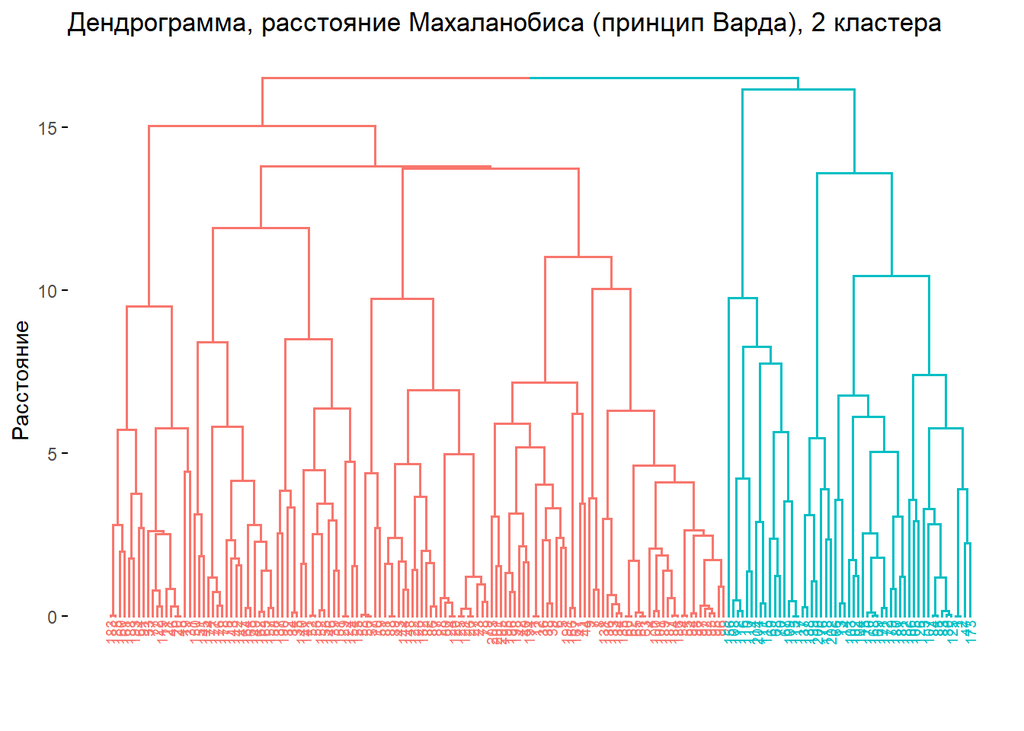

```r
mahalanobis <- sqrt(D2.dist(cluster_df, cov(cluster_df)))
hclust_w <- hclust(mahalanobis, method = 'ward.D2')

# 2 кластера
hclust_w$cluster <- cutree(hclust_w, k = 2)
fviz_dend(hclust_w, cex = 0.5, k = 2, color_labels_by_k = TRUE,
          main = 'Дендрограмма, расстояние Махаланобиса (принцип Варда), 2 кластера', ylab = 'Расстояние')
```

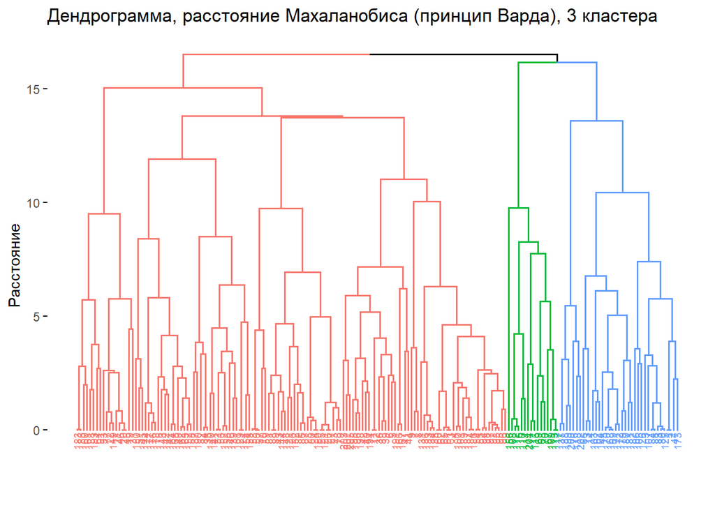

```r
# 3 кластера
hclust_w$cluster <- cutree(hclust_w, k = 3)
fviz_dend(hclust_w, cex = 0.5, k = 3, color_labels_by_k = TRUE,
          main = 'Дендрограмма, расстояние Махаланобиса (принцип Варда), 3 кластера', ylab = 'Расстояние')
```

Согласно дендрограммам разбиение и на 2 и на 3 кластера дает хорошие результаты. Поэтому можно выбрать как 2, так и 3 кластера. Для определения оптимального количества кластеров обратимся к другим методам.

#### **3.2. Метод ближнего соседа**

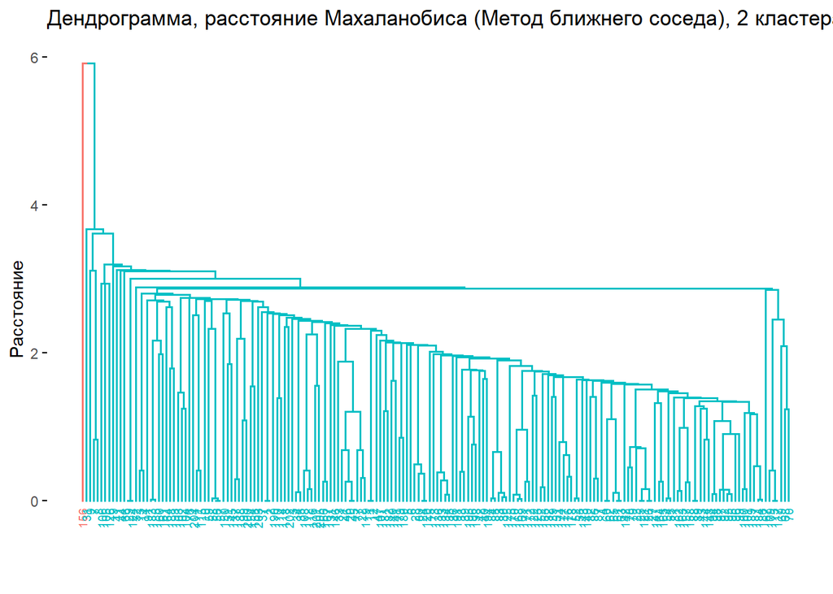

```r
hclust_knn <- hclust(mahalanobis, method = 'single')

# 2 кластера
hclust_knn$cluster <- cutree(hclust_knn, k = 2)
fviz_dend(hclust_knn, cex = 0.5, k = 2, color_labels_by_k = TRUE,
          main = 'Дендрограмма, расстояние Махаланобиса (Метод ближнего соседа), 2 кластера', ylab = 'Расстояние')
```

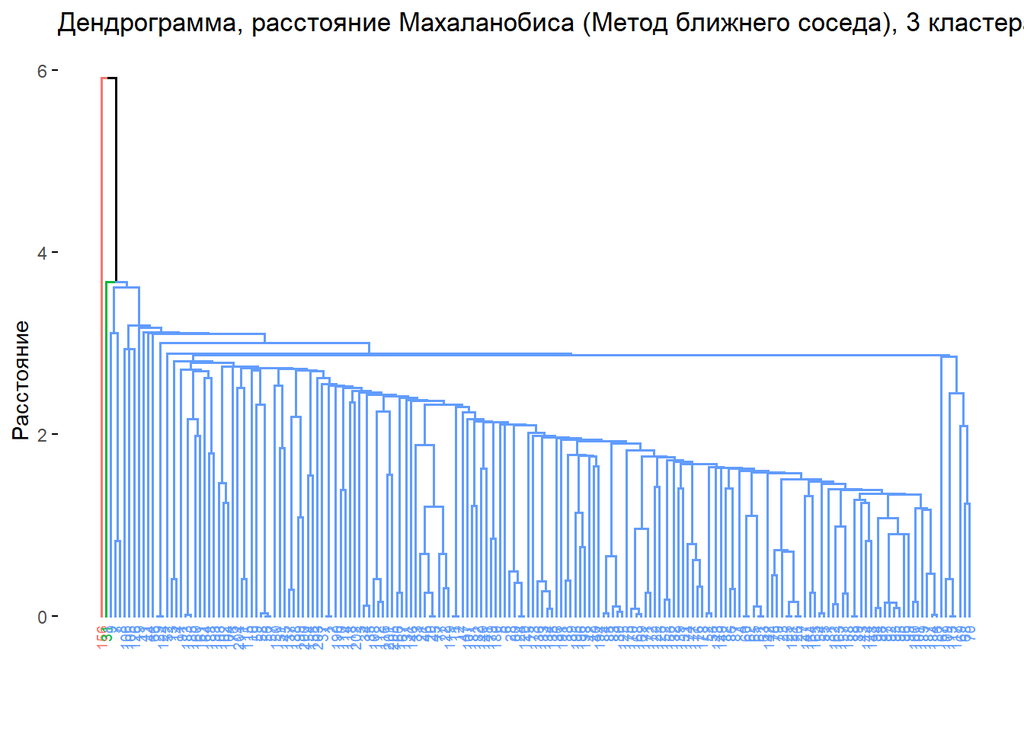

```r
# 3 кластера
hclust_knn$cluster <- cutree(hclust_knn, k = 3)
fviz_dend(hclust_knn, cex = 0.5, k = 3, color_labels_by_k = TRUE,
          main = 'Дендрограмма, расстояние Махаланобиса (Метод ближнего соседа), 3 кластера', ylab = 'Расстояние')
```

Такое разбиение некорректное ни при 2, ни при 3 кластерах (так как тут всего по 1 объекту относится к одному(двум) кластерам, а все остальные объекты к третьему кластеру, что создает несбалансированность классов). Следовательно, лучше вообще не делать кластеризацию.

#### **3.3. Метод дальнего соседа**

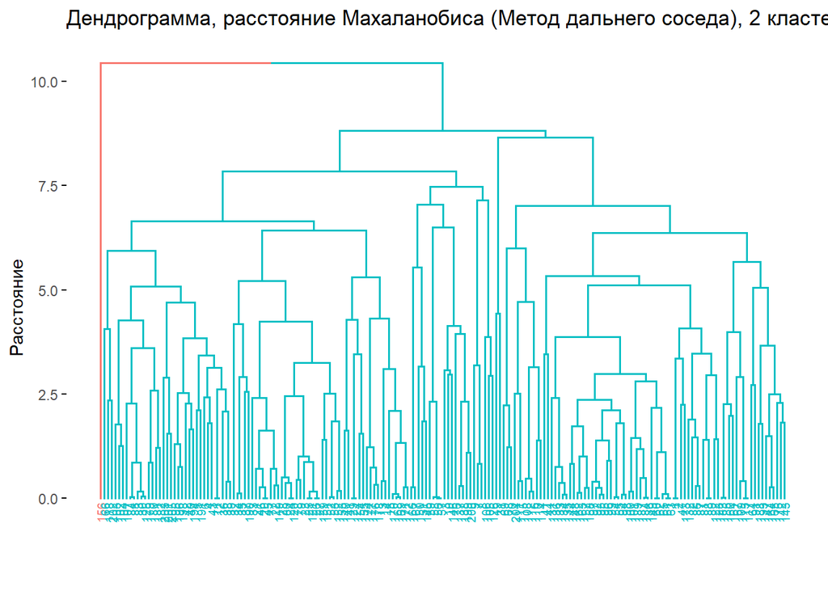

```r
hclust_fn <- hclust(mahalanobis, method = 'complete')

# 2 кластера
hclust_fn$cluster <- cutree(hclust_fn, k = 2)
fviz_dend(hclust_fn, cex = 0.5, k = 2, color_labels_by_k = TRUE,
          main = 'Дендрограмма, расстояние Махаланобиса (Метод дальнего соседа), 2 кластера', ylab = 'Расстояние')
```

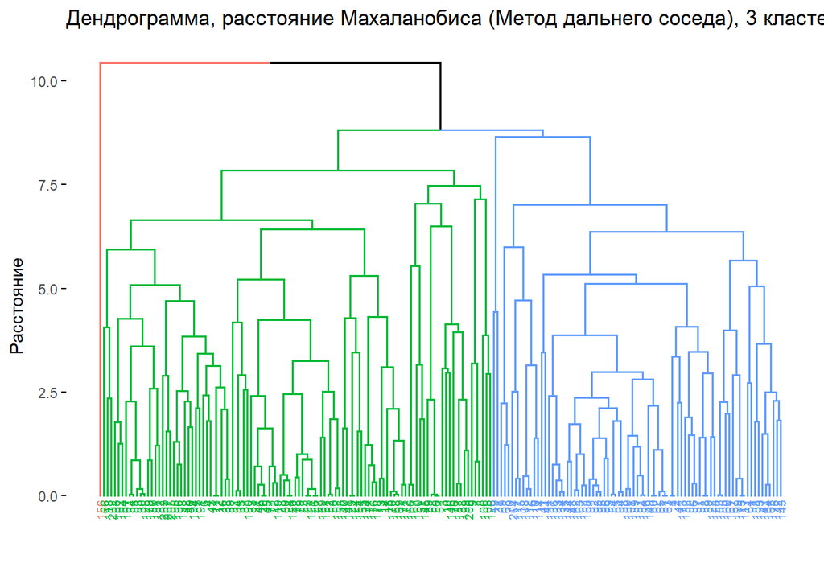

```r
# 3 кластера
hclust_fn$cluster <- cutree(hclust_fn, k = 3)
fviz_dend(hclust_fn, cex = 0.5, k = 3, color_labels_by_k = TRUE,
          main = 'Дендрограмма, расстояние Махаланобиса (Метод дальнего соседа), 3 кластера', ylab = 'Расстояние')
```

Данный метод при 2-ух кластерах показывает несбалансированность классов (к одному кластеру относится всего лишь 1 объект). Делаем вывод, что при данном методе кластеризацию лучше не проводить.

#### **3.4. Метод средней связи**

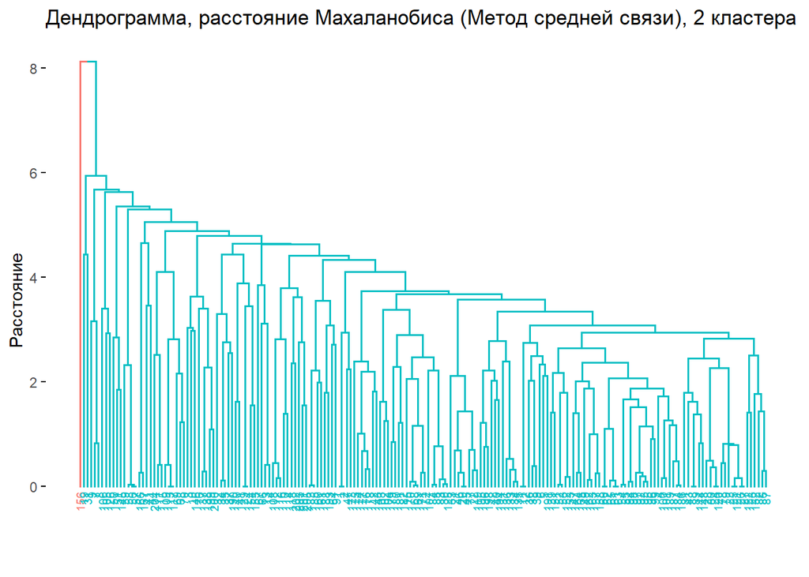

```r
hclust_av <- hclust(mahalanobis, method = 'average')

# 2 кластера
hclust_av$cluster <- cutree(hclust_av, k = 2)
fviz_dend(hclust_av, cex = 0.5, k = 2, color_labels_by_k = TRUE,
          main = 'Дендрограмма, расстояние Махаланобиса (Метод средней связи), 2 кластера', ylab = 'Расстояние')
```

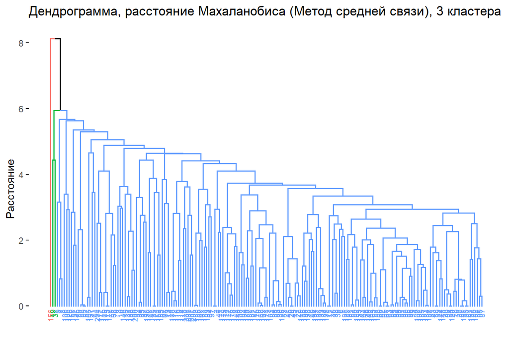

```r
# 3 кластера
hclust_av$cluster <- cutree(hclust_av, k = 3)
fviz_dend(hclust_av, cex = 0.5, k = 3, color_labels_by_k = TRUE,
          main = 'Дендрограмма, расстояние Махаланобиса (Метод средней связи), 3 кластера', ylab = 'Расстояние')
```

Такое разбиение некорректное ни при 2, ни при 3 кластерах (несбалансированность классов). Следовательно, лучше вообще не проводить кластеризацию.

#### **3.5. Метод взвешенного попарного среднего (WPGMA)**

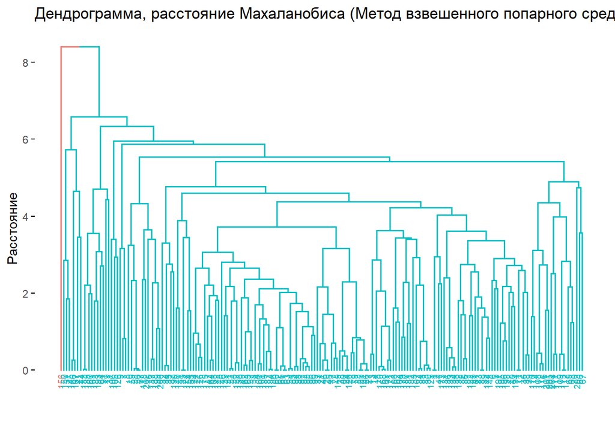

```r
hclust_c <- hclust(mahalanobis, method = 'mcquitty')

# 2 кластера
hclust_c$cluster <- cutree(hclust_c, k = 2)
fviz_dend(hclust_c, cex = 0.5, k = 2, color_labels_by_k = TRUE,
          main = 'Дендрограмма, расстояние Махаланобиса (Метод взвешенного попарного среднего), 2 кластера', ylab = 'Расстояние')
```

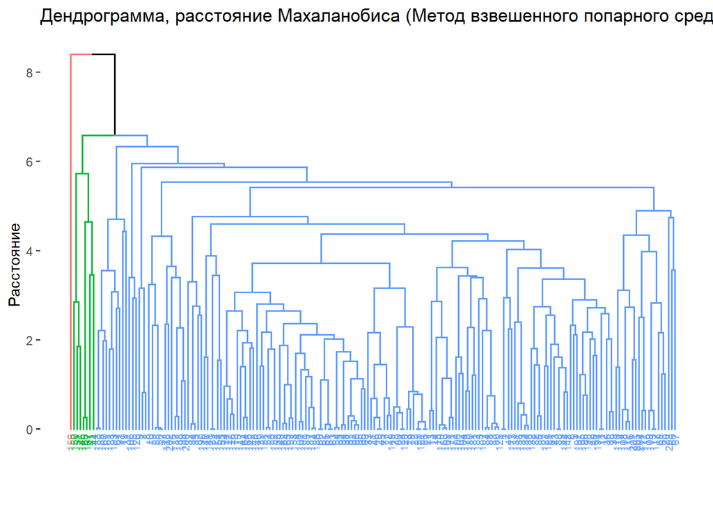

```r
# 3 кластера
hclust_c$cluster <- cutree(hclust_c, k = 3)
fviz_dend(hclust_c, cex = 0.5, k = 3, color_labels_by_k = TRUE,
          main = 'Дендрограмма, расстояние Махаланобиса (Метод взвешенного попарного среднего), 3 кластера', ylab = 'Расстояние')
```

Данный метод показывает также показывает несбалансированность классов как при 2, так и при 3 кластерах. Поэтому кластеризацию лучше не делать.

Сопоставляя все методы, а также методы для определения оптимального числа кластеров, **можно сделать вывод** о том, что оптимальным числом будет разбиение на 2 кластера. Однако, можно выдвинуть альтернативные гипотезы:

1. о разбиении на 3 кластера
2. о том, что кластеризацию лучше не делать

### **Использование метода к-средних для классификации объектов**

Так как в k-means число кластеров является обязательным гиперпараметром, необходимо предварительно выбрать его.

Для выбора оптимального числа кластеров рассмотрим 3 метода:

1. Метод локтя (elbow method).

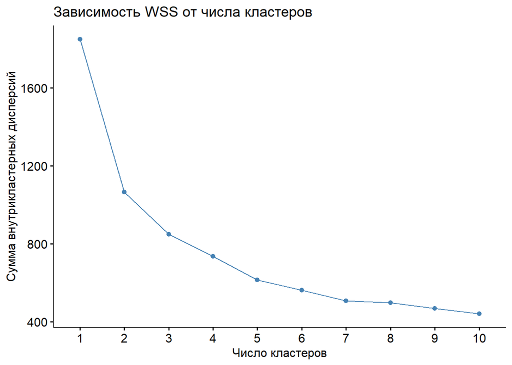

```r
fviz_nbclust(cluster_df, kmeans, method = 'wss') +
  labs(x = 'Число кластеров', y = 'Сумма внутрикластерных дисперсий',
       title = 'Зависимость WSS от числа кластеров')
```

2. Метод силуэтов.

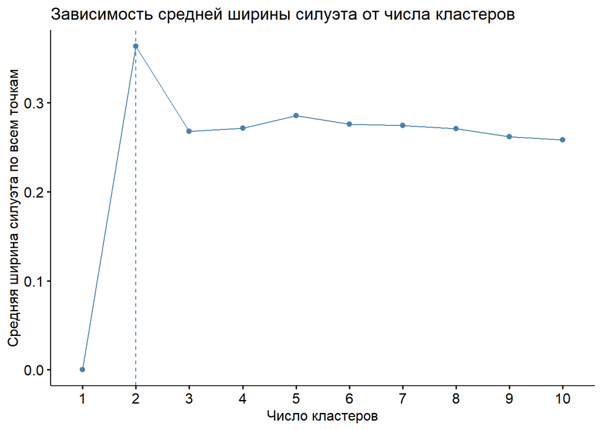

```r
fviz_nbclust(cluster_df, kmeans, method = 'silhouette') +
  labs(x = 'Число кластеров', y = 'Средняя ширина силуэта по всем точкам',
       title = 'Зависимость средней ширины силуэта от числа кластеров')
```

Согласно методу силуэтов: находим точку, которая имеет самый высокий пик, на такое количество кластеров нужно разбивать, в данном случае 2 кластера.

3. Статистика разрыва (Gap-статистика).

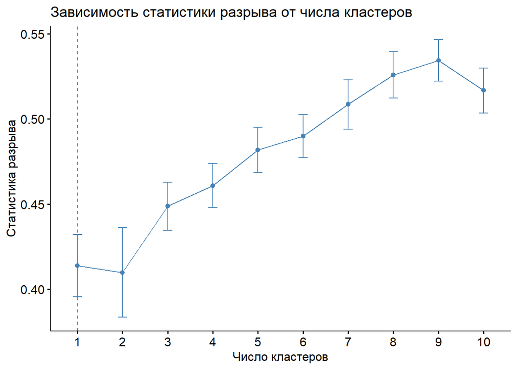

```r
fviz_nbclust(cluster_df, kmeans, method = 'gap_stat') +
  labs(x = 'Число кластеров', y = 'Статистика разрыва',
       title = 'Зависимость статистики разрыва от числа кластеров')
```

Согласно этой статистике рассчитывается разрыв между кластерами, считается статистика. Когда мы получаем, что следующая точка меньше предыдущей, то останавливаемся. В данном случае останавливаемся на 1 кластере. Однако можно заметить, что разница в разрыве между 1 и 2 кластерами незначительная, поэтому в целом можно поделить и на 2 кластера.

Поскольку большинство из этих подходов выбирают 2 в качестве наиболее подходящего числа кластеров, мы выбираем оптимальное число кластеров (на наш взгляд) - **2**.

Установим `seed`, чтобы значения не менялись при повторном запуске, т.к. недостатком k-means является то, что он чувствителен к выбросам, и при изменении порядка данных могут получиться разные результаты.

Реализуем кластеризацию k-means с 2 кластерами(k = 2), установив 2 центра.

```r
set.seed(1)

km2 <- kmeans(cluster_df, centers = 2)
km2
```

```
## K-means clustering with 2 clusters of sizes 109, 77
##
## Cluster means:
##    wheelbase  carlength   carwidth  carheight curbweight enginesize horsepower
## 1 -0.5725575 -0.6098368 -0.6147518 -0.2938466 -0.6752835 -0.6648505 -0.5772064
## 2  0.8105034  0.8632755  0.8702331  0.4159647  0.9559207  0.9411521  0.8170844
##      peakrpm    citympg highwaympg
## 1  0.2422077  0.5063719  0.5190620
## 2 -0.3428655 -0.7168122 -0.7347761
##
## Clustering vector:
##   1   2   3   4   5   6   7   8   9  10  11  12  13  14  15  19  20  21  22  23
##   1   1   2   1   2   2   2   2   2   2   1   1   2   2   2   1   1   1   1   1
##  24  25  26  27  28  29  30  31  32  33  34  35  36  37  38  39  40  41  42  43
##   1   1   1   1   1   2   2   1   1   1   1   1   1   1   1   1   1   1   1   1
##  44  45  46  47  51  52  53  54  55  56  57  58  59  60  61  62  63  64  65  66
##   1   1   1   1   1   1   1   1   1   1   1   1   1   1   2   1   2   1   2   2
##  67  68  69  70  76  77  78  79  80  81  82  83  84  85  86  87  88  89  91  92
##   2   2   2   2   2   1   1   1   1   1   1   2   2   2   1   1   1   1   1   1
##  93  94  95  96  97  98  99 100 101 102 103 104 105 106 107 108 109 110 111 112
##   1   1   1   1   1   1   1   1   1   2   2   2   2   2   2   2   2   2   2   2
## 113 114 115 116 117 118 119 120 121 122 123 124 125 126 131 132 133 134 135 136
##   2   2   2   2   2   2   1   1   1   1   1   2   2   2   2   1   2   2   2   2
## 137 138 139 140 141 142 143 144 145 146 147 148 149 150 151 152 153 154 155 156
##   2   2   1   1   1   1   1   1   1   1   1   1   1   2   1   1   1   1   1   1
## 157 158 160 161 162 163 164 165 166 167 168 169 170 171 172 173 174 175 176 177
##   1   1   1   1   1   1   1   1   1   1   2   2   2   2   2   2   2   1   2   2
## 178 179 180 181 182 183 184 185 186 187 188 189 190 191 193 194 195 196 198 199
##   2   2   2   2   2   1   1   1   1   1   1   1   1   1   1   2   2   2   2   2
## 200 201 202 203 204 205
##   2   2   2   2   2   2
##
## Within cluster sum of squares by cluster:
## [1] 570.5237 494.9272
##  (between_SS / total_SS =  42.4 %)
##
## Available components:
##
## [1] "cluster"      "centers"      "totss"        "withinss"     "tot.withinss"
## [6] "betweenss"    "size"         "iter"         "ifault"
```

Т.к. мы посчитали, что нет смысла в разбиение на 2 кластера, может есть смысл в разбиении на 3 кластера, т.к. один из методов определения оптимального числа кластеров показал, что возможно 3 будет лучшим вариантом.

```r
set.seed(1)

kmeans <- kmeans(cluster_df, centers = 3)
kmeans
```

```
## K-means clustering with 3 clusters of sizes 58, 71, 57
##
## Cluster means:
##    wheelbase   carlength   carwidth  carheight curbweight enginesize
## 1 -0.7478481 -1.00025685 -0.8744587 -0.2444979 -1.0445038 -0.8853521
## 2 -0.1731451 -0.02341139 -0.1779446 -0.1665890 -0.1423745 -0.1796913
## 3  0.9766402  1.04696676  1.1114504  0.4562929  1.2401722  1.1247106
##    horsepower     peakrpm    citympg highwaympg
## 1 -0.98811838  0.06421602  1.1378534  1.1343677
## 2 -0.07239342  0.09975532 -0.1917531 -0.1634814
## 3  1.09562806 -0.18959924 -0.9189655 -0.9506341
##
## Clustering vector:
##   1   2   3   4   5   6   7   8   9  10  11  12  13  14  15  19  20  21  22  23
##   2   2   3   2   3   2   3   3   3   3   2   2   3   3   3   1   1   1   1   1
##  24  25  26  27  28  29  30  31  32  33  34  35  36  37  38  39  40  41  42  43
##   2   1   1   1   2   2   3   1   1   1   1   1   1   1   2   2   2   2   2   2
##  44  45  46  47  51  52  53  54  55  56  57  58  59  60  61  62  63  64  65  66
##   2   1   1   2   1   1   1   1   1   2   2   2   2   2   2   2   2   1   2   3
##  67  68  69  70  76  77  78  79  80  81  82  83  84  85  86  87  88  89  91  92
##   2   3   3   3   3   1   1   1   2   2   2   3   3   3   2   2   2   2   1   1
##  93  94  95  96  97  98  99 100 101 102 103 104 105 106 107 108 109 110 111 112
##   1   1   1   1   1   1   1   2   2   3   3   3   3   3   3   3   3   3   3   3
## 113 114 115 116 117 118 119 120 121 122 123 124 125 126 131 132 133 134 135 136
##   3   3   3   3   3   3   1   2   1   1   1   2   3   3   2   2   3   3   3   3
## 137 138 139 140 141 142 143 144 145 146 147 148 149 150 151 152 153 154 155 156
##   3   3   1   1   1   1   2   2   2   2   2   2   2   2   1   1   1   1   2   2
## 157 158 160 161 162 163 164 165 166 167 168 169 170 171 172 173 174 175 176 177
##   1   1   1   1   1   1   1   1   2   2   2   2   2   2   2   2   2   2   2   2
## 178 179 180 181 182 183 184 185 186 187 188 189 190 191 193 194 195 196 198 199
##   2   3   3   3   3   1   2   1   2   2   1   2   2   2   2   2   3   3   3   3
## 200 201 202 203 204 205
##   3   3   3   3   3   3
##
## Within cluster sum of squares by cluster:
## [1] 198.5431 305.7789 347.3310
##  (between_SS / total_SS =  54.0 %)
##
## Available components:
##
## [1] "cluster"      "centers"      "totss"        "withinss"     "tot.withinss"
## [6] "betweenss"    "size"         "iter"         "ifault"
```

Из результатов мы видим, что:

Очевидно, что разницу между кластерами увеличилась и стала 54.0%. Теперь мы можем говорить о возможном разделении наших данных на 3 кластера.

Визуализируем результаты кластеризации через график средних. По графику средних даем интерпретацию полученным кластерам.

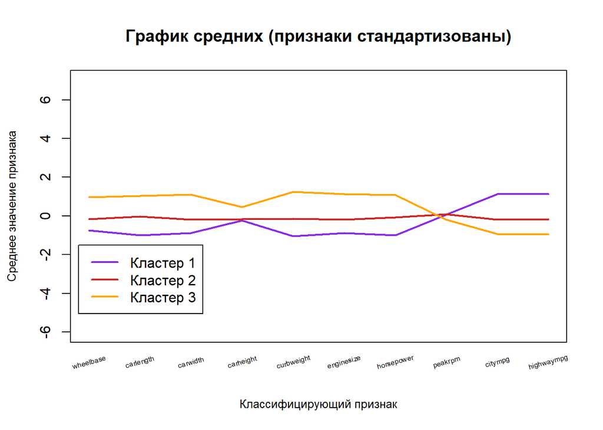

```r
plot(1:ncol(cluster_df), kmeans$centers[1,], xaxt = 'n', type = 'l', col = 'blueviolet',
     cex.sub = 0.3, cex.lab = 0.8, lwd = 2, ylim = c(-6, 7),
     ylab = 'Среднее значение признака', xlab = 'Классифицирующий признак')

lines(1:ncol(cluster_df), kmeans$centers[2,], type = 'l', col = 'firebrick3', lwd = 2)
lines(1:ncol(cluster_df), kmeans$centers[3,], type = 'l', col = 'orange', lwd = 2)



title('График средних (признаки стандартизованы)')
legend(0.8, -1.5, c('Кластер 1', 'Кластер 2', 'Кластер 3'),
       lwd = c(2, 2, 2), col = c('blueviolet', 'firebrick3', 'orange'))
text(x =  seq_along(names(cluster_df)), y = par("usr")[3] - 1, srt = 15, adj = 0.5,
     labels = names(cluster_df), xpd = TRUE, cex = 0.5)
```

В целом, различия между кластерами не особо большие, но нельзя сказать, что его нет.

Средние значения для признака `peakrpm` очень близки(почти равны), это может быть связано с тем что, что количество оборотов, при которых достигается максимальная мощность двигателя не сильно меняется от кластера кластеру и не влияет на классификацию как таковую.

При построении корреляционной матрицы этот признак имел очень маленькую корреляцию с остальными, поэтому возможно он бесполезен в оценки автомобилей в принципе.

Если не считать его и переменную `carheight`, которая близка для 1 и 2 кластеров, то можно сказать, что средние не пересекаются и находятся друг от друга примерно на одном расстоянии для остальных признаков.

Для того чтобы подтвердить свои предположения проведем тест на равенство средних по переменным для полученных кластеров (ANOVA):

```r
pander(summary(aov(cluster_df$wheelbase ~ as.factor(kmeans$cluster))))
```

Analysis of Variance Model

|  | Df | Sum Sq | Mean Sq | F value | Pr(>F) |
| --- | --- | --- | --- | --- | --- |
| **as.factor(kmeans$cluster)** | 2 | 88.93 | 44.47 | 84.71 | 9.092e-27 |
| **Residuals** | 183 | 96.07 | 0.5249 | NA | NA |

```r
pander(summary(aov(cluster_df$carlength ~ as.factor(kmeans$cluster))))
```

Analysis of Variance Model

|  | Df | Sum Sq | Mean Sq | F value | Pr(>F) |
| --- | --- | --- | --- | --- | --- |
| **as.factor(kmeans$cluster)** | 2 | 120.5 | 60.27 | 171.1 | 1.255e-42 |
| **Residuals** | 183 | 64.45 | 0.3522 | NA | NA |

```r
pander(summary(aov(cluster_df$carwidth ~ as.factor(kmeans$cluster))))
```

Analysis of Variance Model

|  | Df | Sum Sq | Mean Sq | F value | Pr(>F) |
| --- | --- | --- | --- | --- | --- |
| **as.factor(kmeans$cluster)** | 2 | 117 | 58.51 | 157.5 | 1.663e-40 |
| **Residuals** | 183 | 67.99 | 0.3715 | NA | NA |

```r
pander(summary(aov(cluster_df$carheight ~ as.factor(kmeans$cluster))))
```

Analysis of Variance Model

|  | Df | Sum Sq | Mean Sq | F value | Pr(>F) |
| --- | --- | --- | --- | --- | --- |
| **as.factor(kmeans$cluster)** | 2 | 17.31 | 8.653 | 9.442 | 0.0001251 |
| **Residuals** | 183 | 167.7 | 0.9164 | NA | NA |

```r
pander(summary(aov(cluster_df$curbweight ~ as.factor(kmeans$cluster))))
```

Analysis of Variance Model

|  | Df | Sum Sq | Mean Sq | F value | Pr(>F) |
| --- | --- | --- | --- | --- | --- |
| **as.factor(kmeans$cluster)** | 2 | 152.4 | 76.19 | 427.5 | 1.078e-69 |
| **Residuals** | 183 | 32.62 | 0.1782 | NA | NA |

```r
pander(summary(aov(cluster_df$enginesize ~ as.factor(kmeans$cluster))))
```

Analysis of Variance Model

|  | Df | Sum Sq | Mean Sq | F value | Pr(>F) |
| --- | --- | --- | --- | --- | --- |
| **as.factor(kmeans$cluster)** | 2 | 119.9 | 59.93 | 168.4 | 3.321e-42 |
| **Residuals** | 183 | 65.14 | 0.356 | NA | NA |

```r
pander(summary(aov(cluster_df$horsepower ~ as.factor(kmeans$cluster))))
```

Analysis of Variance Model

|  | Df | Sum Sq | Mean Sq | F value | Pr(>F) |
| --- | --- | --- | --- | --- | --- |
| **as.factor(kmeans$cluster)** | 2 | 125.4 | 62.71 | 192.6 | 9.381e-46 |
| **Residuals** | 183 | 59.58 | 0.3255 | NA | NA |

```r
pander(summary(aov(cluster_df$peakrpm ~ as.factor(kmeans$cluster))))
```

Analysis of Variance Model

|  | Df | Sum Sq | Mean Sq | F value | Pr(>F) |
| --- | --- | --- | --- | --- | --- |
| **as.factor(kmeans$cluster)** | 2 | 2.995 | 1.497 | 1.506 | 0.2246 |
| **Residuals** | 183 | 182 | 0.9946 | NA | NA |

```r
pander(summary(aov(cluster_df$citympg ~ as.factor(kmeans$cluster))))
```

Analysis of Variance Model

|  | Df | Sum Sq | Mean Sq | F value | Pr(>F) |
| --- | --- | --- | --- | --- | --- |
| **as.factor(kmeans$cluster)** | 2 | 125.8 | 62.92 | 194.6 | 4.946e-46 |
| **Residuals** | 183 | 59.16 | 0.3233 | NA | NA |

```r
pander(summary(aov(cluster_df$highwaympg ~ as.factor(kmeans$cluster))))
```

Analysis of Variance Model

|  | Df | Sum Sq | Mean Sq | F value | Pr(>F) |
| --- | --- | --- | --- | --- | --- |
| **as.factor(kmeans$cluster)** | 2 | 128 | 64.02 | 205.7 | 1.537e-47 |
| **Residuals** | 183 | 56.96 | 0.3112 | NA | NA |

Во всех случаях (кроме переменной `peakrpm`) p-value < 0.05. Следовательно, на уровне значимости 5% нулевая гипотеза (о том, что средние всех уровней фактора равны) отвергается в пользу альтернативной (что между какими-то уровнями есть разница в средних значениях `wheelbase`, `carlength`, `carwidth`, `carheight`, `curbweight`, `enginesize`, `horsepower`, `citympg`).

Добавим кластерные значения обратно в исходный набор данных, чтобы интерпретировать получившиеся кластеры.

```r
final_data <- cbind(df_new, cluster = kmeans$cluster)

tail(final_data)
```

```
##     wheelbase carlength carwidth carheight curbweight enginesize horsepower
## 200     104.3     188.8     67.2      57.5       3157        130        162
## 201     109.1     188.8     68.9      55.5       2952        141        114
## 202     109.1     188.8     68.8      55.5       3049        141        160
## 203     109.1     188.8     68.9      55.5       3012        173        134
## 204     109.1     188.8     68.9      55.5       3217        145        106
## 205     109.1     188.8     68.9      55.5       3062        141        114
##     peakrpm citympg highwaympg price cluster
## 200    5100      17         22 18950       3
## 201    5400      23         28 16845       3
## 202    5300      19         25 19045       3
## 203    5500      18         23 21485       3
## 204    4800      26         27 22470       3
## 205    5400      19         25 22625       3
```

Изначально мы выкидывали переменную `price`, которая является целевой в наших данных. Посмотрим какая корреляция между получившимся разделением на кластеры и ценой машины в $.

```r
cor(final_data$price, final_data$cluster)
```

```
## [1] 0.8143508
```

Достаточно сильная корреляция, можно сказать, что получившаяся классификация делит наш дата сет авто на 3 кластера: дешевые, средней ценовой категории и дорогие машины.

Посмотрим какие средние `price` значения принимает каждый из кластеров, чтобы подтвердить нашу гипотезу о разделении данных по “ценовым” кластерам.

```r
n <- data.frame(final_data$price, final_data$cluster)
head(n)
```

```
##   final_data.price final_data.cluster
## 1            13495                  2
## 2            16500                  2
## 3            16500                  3
## 4            13950                  2
## 5            17450                  3
## 6            15250                  2
```

```r
x1 <- c()
x2 <- c()
x3 <- c()

for (i in  1:186) {
  if (n$final_data.cluster[i] == 1) {
    x1 <- c(x1, n$final_data.price[i])
  }else if (n$final_data.cluster[i] == 2) {
    x2 <- c(x2, n$final_data.price[i])
  } else {
    x3 <- c(x3, n$final_data.price[i])
  }
}

print(mean(x1))
```

```
## [1] 7073.362
```

```r
print(mean(x2))
```

```
## [1] 10468.85
```

```r
print(mean(x3))
```

```
## [1] 17378.35
```

Мы также можем просмотреть наши результаты с помощью `fviz_cluster`. Это дает хорошую иллюстрацию кластеров.

Т.к. у нас более двух переменных `fviz_cluster` выполнит анализ главных компонентов (PCA) и нанесет точки данных в соответствии с первыми двумя основными компонентами, которые объясняют большую часть дисперсии.

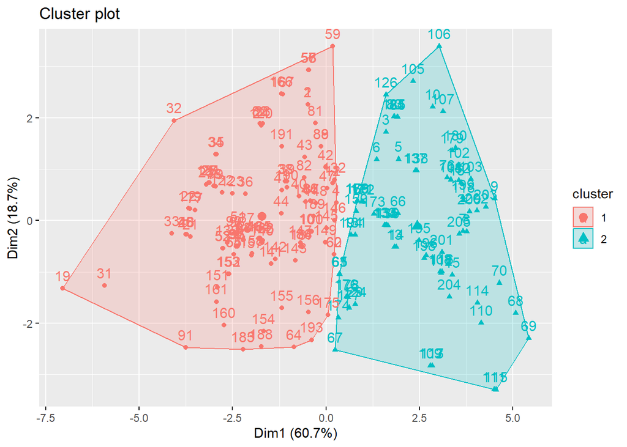

```r
fviz_cluster(km2, data = cluster_df)
```

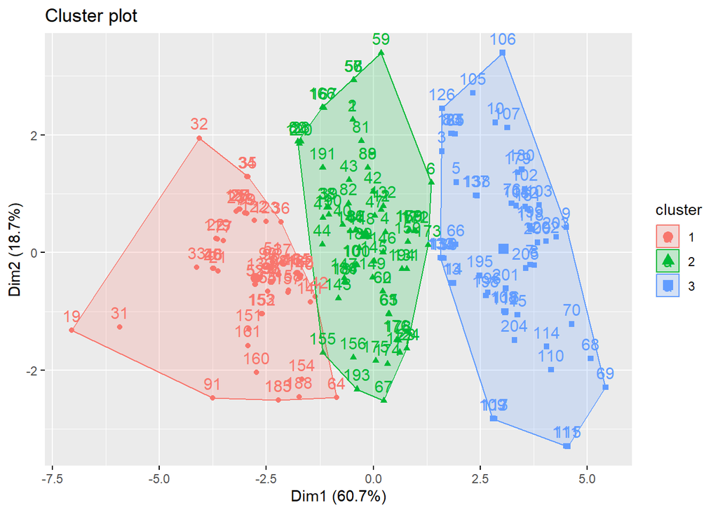

```r
fviz_cluster(kmeans, data = cluster_df)
```

В целом оба разбиения на кластеры показывают не плохие результаты, что видно на графиках. Только в случае 2 кластеров, есть области в которой кластеры очень близки, поэтому методом k-means не удалась разделить их(отношение межгрупповой дисперсии к внутригрупповой было немного меньше нормального).

В случае же 3 кластеров, они тоже достаточно близки, но не пересекаются. Т. к. достаточно сложно провести четкую ценовую границу между разными классами авто по цене, поэтому наши кластеры расположены достаточно близко друг к другу, но при этом все же разделены.

### **Построение регрессионных моделей в кластерах**

#### **5.1. Построение уравнений регрессии в кластерах**

Ранее мы уже построили линейную регрессионную модель для всей совокупности объектов. Она выглядела следующим образом:

$y_i=−52048.412+5.732∗curbweight_i+39.750∗horsepower_i+746.198∗carwidth_i−76.670∗carlength_i+99.215∗wheelbase_i+\varepsilon_i$ Теперь построим регрессионные модели для каждого класса отдельно, включив те же переменные, что и в модель для всей совокупности.

Добавим к исходным данным вектор-столбец со значением кластера для каждого наблюдения.

```r
cl <- kmeans$cluster
data_regress <- as.data.frame(cbind(df_new, cl))
```

Теперь разделим датафрейм на три в соответствии с классами.

```r
class_1 <- data_regress[data_regress$cl == 1, ]
class_2 <- data_regress[data_regress$cl == 2, ]
class_3 <- data_regress[data_regress$cl == 3, ]
```

Удалим столбец “cl”, так как для построения регрессии он нам не нужен.

```r
class_1 <- subset(class_1, select = - c(cl))
class_2 <- subset(class_2, select = - c(cl))
class_3 <- subset(class_3, select = - c(cl))
```

Построим регрессионные модели для каждого класса:

```r
lm_class1 <- lm(price ~ curbweight + horsepower + carwidth + carlength + wheelbase, data = class_1)
(summary(lm_class1))
```

```
##
## Call:
## lm(formula = price ~ curbweight + horsepower + carwidth + carlength +
##     wheelbase, data = class_1)
##
## Residuals:
##      Min       1Q   Median       3Q      Max
## -1884.96  -531.84   -89.62   405.75  2530.41
##
## Coefficients:
##              Estimate Std. Error t value Pr(>|t|)
## (Intercept) -9248.704  13301.232  -0.695   0.4899
## curbweight      3.256      1.385   2.352   0.0225 *
## horsepower     17.859     19.579   0.912   0.3659
## carwidth      122.908    221.566   0.555   0.5815
## carlength      38.875     27.971   1.390   0.1705
## wheelbase     -59.204     89.977  -0.658   0.5134
## ---
## Signif. codes:  0 '***' 0.001 '**' 0.01 '*' 0.05 '.' 0.1 ' ' 1
##
## Residual standard error: 891.5 on 52 degrees of freedom
## Multiple R-squared:  0.4332, Adjusted R-squared:  0.3786
## F-statistic: 7.947 on 5 and 52 DF,  p-value: 1.275e-05
```

Для первого класса уравнение регрессии выглядит следующим образом:

$$y_i=−9249+3.256∗curbweight_i+17.86∗horsepower_i+122.9∗carwidth_i+38.87∗carlength_i-59.2∗wheelbase_i+\varepsilon_i$$

Коэффициент детерминации равен 0,4332, то есть 43,32% изменений в цене (y) объясняется изменениями регрессоров. Из всех коэффициентов значим только один (на уровне значимости 0,05), при переменной curbweight. Само уравнение линейной регрессии значимо, так как значение p-value значительно меньше 0,05.

```r
lm_class2 <- lm(price ~ curbweight + horsepower + carwidth + carlength + wheelbase, data = class_2)
(summary(lm_class2))
```

```
##
## Call:
## lm(formula = price ~ curbweight + horsepower + carwidth + carlength +
##     wheelbase, data = class_2)
##
## Residuals:
##     Min      1Q  Median      3Q     Max
## -4084.5 -1206.6  -547.3   734.0  6359.1
##
## Coefficients:
##               Estimate Std. Error t value Pr(>|t|)
## (Intercept) -33997.604  17643.937  -1.927  0.05837 .
## curbweight       6.178      1.800   3.431  0.00105 **
## horsepower      57.083     19.944   2.862  0.00565 **
## carwidth       236.760    361.295   0.655  0.51458
## carlength      -22.000     80.316  -0.274  0.78502
## wheelbase      127.672    124.425   1.026  0.30865
## ---
## Signif. codes:  0 '***' 0.001 '**' 0.01 '*' 0.05 '.' 0.1 ' ' 1
##
## Residual standard error: 2254 on 65 degrees of freedom
## Multiple R-squared:  0.3215, Adjusted R-squared:  0.2694
## F-statistic: 6.161 on 5 and 65 DF,  p-value: 9.871e-05
```

Для второго класса:

$$y_i=−33997.604+6.178∗curbweight_i+57.083∗horsepower_i+236.76∗carwidth_i-22∗carlength_i+127.672∗wheelbase_i+\varepsilon_i$$

Коэффициент детерминации равен 0,3215, то есть 32,15% изменений в цене (y) объясняется изменениями регрессоров. Из всех коэффициентов значимы два(на уровне значимости 0,05), при переменных curbweight и horsepower. Само уравнение линейной регрессии значимо, так как значение p-value значительно меньше 0,05 (9.871e-05).

```r
lm_class3 <- lm(price ~ curbweight + horsepower + carwidth + carlength + wheelbase, data = class_3)
(summary(lm_class3))
```

```
##
## Call:
## lm(formula = price ~ curbweight + horsepower + carwidth + carlength +
##     wheelbase, data = class_3)
##
## Residuals:
##     Min      1Q  Median      3Q     Max
## -5740.9 -2189.3  -966.5  2076.7  9050.4
##
## Coefficients:
##               Estimate Std. Error t value Pr(>|t|)
## (Intercept) -58011.566  23792.997  -2.438  0.01828 *
## curbweight       3.320      2.739   1.212  0.23109
## horsepower      27.109     23.289   1.164  0.24983
## carwidth      1135.007    383.659   2.958  0.00468 **
## carlength     -180.315    114.293  -1.578  0.12083
## wheelbase      176.347    182.841   0.964  0.33935
## ---
## Signif. codes:  0 '***' 0.001 '**' 0.01 '*' 0.05 '.' 0.1 ' ' 1
##
## Residual standard error: 3396 on 51 degrees of freedom
## Multiple R-squared:  0.3095, Adjusted R-squared:  0.2418
## F-statistic: 4.571 on 5 and 51 DF,  p-value: 0.001607
```

Для третьего класса:

$$y_i=−58011.566+3.32∗curbweight_i+27.109∗horsepower_i+1135.007∗carwidth_i-180.315∗carlength_i+176.347∗wheelbase_i+\varepsilon_i$$

Коэффициент детерминации равен 0,3095, то есть 30,95% изменений в цене (y) объясняется изменениями регрессоров. Из всех коэффициентов значим только один (на уровне значимости 0,05), при переменной carwidth. Само уравнение линейной регрессии значимо, так как значение p-value меньше 0,05 (0.001607).

#### **5.2. Сопоставление и интерпретация коэффициентов регрессии в кластерах с использованием коэффициентов эластичности**

Найдем коэффициенты эластичности для регрессионных моделей.

1 класс (дешевые авто):

$$y_i=−9249+3.256∗curbweight_i+17.86∗horsepower_i+122.9∗carwidth_i+38.87∗carlength_i-59.2∗wheelbase_i+\varepsilon_i$$

2 класс ( авто средней ценовой категории):

$$y_i=−33997.604+6.178∗curbweight_i+57.083∗horsepower_i+236.76∗carwidth_i-22∗carlength_i+127.672∗wheelbase_i+\varepsilon_i$$

3 класс (дорогие авто):

$$y_i=−58011.566+3.32∗curbweight_i+27.109∗horsepower_i+1135.007∗carwidth_i-180.315∗carlength_i+176.347∗wheelbase_i+\varepsilon_i$$

```r
class_1$pred <- predict(lm_class1)
class_2$pred <- predict(lm_class2)
class_3$pred <- predict(lm_class3)
```

```r
paste('Эластичность curbweight класс 1: ', round((3.256*mean(class_1$curbweight)/mean(class_1$pred)), 3), '%',
      'Эластичность curbweight класс 2: ', round((6.178*mean(class_2$curbweight)/mean(class_2$pred)), 3), '%',
      'Эластичность curbweight класс 3: ', round((3.32*mean(class_3$curbweight)/mean(class_3$pred)), 3), '%')
```

```
## [1] "Эластичность curbweight класс 1:  0.927 % Эластичность curbweight класс 2:  1.427 % Эластичность curbweight класс 3:  0.58 %"
```

Цена автомобиля первого класса в среднем вырастет на 0,927%, при росте веса автомобиля на 1% от своего среднего уровня. Цена автомобиля второго класса в среднем вырастет на 1,427%, при росте веса автомобиля на 1% от своего среднего уровня. Цена автомобиля третьего класса в среднем вырастет на 0,58%, при росте веса автомобиля на 1% от своего среднего уровня. Таким образом, мы видим, что фактор “вес автомобиля” влияет положительно на цену авто всех классов, для второго класса он имеет больший эффект, чем для первого и третьего.

```r
paste('Эластичность horsepower класс 1: ', round((17.86*mean(class_1$horsepower)/mean(class_1$pred)), 3), '%',
      'Эластичность horsepower класс 2: ', round((57.083*mean(class_2$horsepower)/mean(class_2$pred)), 3), '%',
      'Эластичность horsepower класс 3: ', round((27.109*mean(class_3$horsepower)/mean(class_3$pred)), 3), '%')
```

```
## [1] "Эластичность horsepower класс 1:  0.17 % Эластичность horsepower класс 2:  0.519 % Эластичность horsepower класс 3:  0.204 %"
```

Цена автомобиля первого класса в среднем вырастет на 0,17%, при росте лошадиных сил на 1% от своего среднего уровня. Цена автомобиля второго класса в среднем вырастет на 0,519%, при росте лошадиных сил на 1% от своего среднего уровня. Цена автомобиля третьего класса в среднем вырастет на 0,204%, при росте лошадиных сил на 1% от своего среднего уровня. Фактор “лошадиные силы” оказывает положительное влияние на цену машин всех классов, для второго класса мы получили наибольший коэффициент эластичности, что говорит нам о том, что на второй класс этот фактор влияет сильнее, чем на первый и третий.

```r
paste('Эластичность carwidth класс 1: ', round((122.9*mean(class_1$carwidth)/mean(class_1$pred)), 3), '%',
      'Эластичность carwidth класс 2: ', round((236.76*mean(class_2$carwidth)/mean(class_2$pred)), 3), '%',
      'Эластичность carwidth класс 3: ', round((1135.007*mean(class_3$carwidth)/mean(class_3$pred)), 3), '%')
```

```
## [1] "Эластичность carwidth класс 1:  1.112 % Эластичность carwidth класс 2:  1.477 % Эластичность carwidth класс 3:  4.421 %"
```

Цена автомобиля первого класса в среднем вырастет на 1,112%, при росте ширины автомобиля на 1% от своего среднего уровня. Цена автомобиля второго класса в среднем вырастет на 1,477%, при росте ширины автомобиля на 1% от своего среднего уровня. Цена автомобиля третьего класса в среднем вырастет на 4,421%, при росте ширины автомобиля на 1% от своего среднего уровня. Фактор “ширина автомобиля” оказывает положительное влияние на цену автомобилей всех классов, при этом изменение этого фактора в наибольшей степени оказывают влияние на третий класс.

```r
paste('Эластичность carlength класс 1: ', round((38.87*mean(class_1$carlength)/mean(class_1$pred)), 3), '%',
      'Эластичность carlength класс 2: ', round((-22*mean(class_2$carlength)/mean(class_2$pred)), 3), '%',
      'Эластичность carlength класс 3: ', round((-180.315*mean(class_3$carlength)/mean(class_3$pred)), 3), '%')
```

```
## [1] "Эластичность carlength класс 1:  0.887 % Эластичность carlength класс 2:  -0.362 % Эластичность carlength класс 3:  -1.916 %"
```

Цена автомобиля первого класса в среднем увеличится на 0,887%, при росте длины автомобиля на 1% от своего среднего уровня. Цена автомобиля второго класса в среднем уменьшится на 0,362%, при росте длины автомобиля на 1% от своего среднего уровня. Цена автомобиля третьего класса в среднем уменьшится на 1,916%, при росте длины автомобиля на 1% от своего среднего уровня. Переменная “длина автомобиля” положительно влияет на цену авто первого класса, отрицательно на цену второго и третьего, самое сильное воздействие она оказывает на третий класс.

```r
paste('Эластичность wheelbase класс 1: ', round((-59.2*mean(class_1$wheelbase)/mean(class_1$pred)), 3), '%',
      'Эластичность wheelbase класс 2: ', round((127.672*mean(class_2$wheelbase)/mean(class_2$pred)), 3), '%',
      'Эластичность wheelbase класс 3: ', round((176.347*mean(class_3$wheelbase)/mean(class_3$pred)), 3), '%')
```

```
## [1] "Эластичность wheelbase класс 1:  -0.789 % Эластичность wheelbase класс 2:  1.187 % Эластичность wheelbase класс 3:  1.05 %"
```

Цена автомобиля первого класс в среднем уменьшится на 0,789%, при росте расстояния между передними и задними колесами на 1% от своего среднего уровня. Цена автомобиля второго класса в среднем увеличится на 1,187%, при росте расстояния между передними и задними колесами на 1% от своего среднего уровня. Цена автомобиля третьего класса в среднем увеличится на 1,05%, при росте расстояния между передними и задними колесами на 1% от своего среднего уровня. Фактор “расстояние между передними и задними колесами” оказывает отрицательное воздействие на цену авто первого класса, положительное на цены авто второго и третьего классов. Наибольший эффект этот фактор имеет при воздействии на второй класс.

Таким образом, мы можем проранжировать факторы для каждого класса по силе влияния следующим образом:

1 класс: 1) carwidth; 2) curbweight; 3) carlength; 4) wheelbase; 5) horsepower 2 класс: 1) carwidth; 2) curbweight; 3) wheelbase; 4) horsepower; 5) carlength

3 класс: 1) carwidth; 2) carlength; 3) wheelbase; 4) curbweight; 5)horsepower Таким образом, наибольшее влияние на цену авто каждого класса оказывает переменная “carwidth”, также у первого и второго классов совпадают вторые по силе влияния факторы (curbweight), а у второго и третьего класса фактор, который на третьем месте по силе влияния (wheelbase).

#### **5.3. Сопоставление качества построенных моделей в кластерах и для всей совокупности объектов в целом**

Еще раз построим линейную регрессионную модель по всей совокупности.

```r
lm5 <- lm(price ~ curbweight + horsepower + carwidth + carlength + wheelbase, data = df_new)
(summary(lm5))
```

```
##
## Call:
## lm(formula = price ~ curbweight + horsepower + carwidth + carlength +
##     wheelbase, data = df_new)
##
## Residuals:
##     Min      1Q  Median      3Q     Max
## -4988.4 -1339.0  -510.3   725.5  8603.1
##
## Coefficients:
##               Estimate Std. Error t value Pr(>|t|)
## (Intercept) -52089.378   9991.957  -5.213 5.06e-07 ***
## curbweight       5.721      1.100   5.203 5.31e-07 ***
## horsepower      39.736      9.879   4.022 8.47e-05 ***
## carwidth       748.418    198.022   3.779 0.000214 ***
## carlength      -76.893     39.379  -1.953 0.052410 .
## wheelbase       98.841     75.536   1.309 0.192365
## ---
## Signif. codes:  0 '***' 0.001 '**' 0.01 '*' 0.05 '.' 0.1 ' ' 1
##
## Residual standard error: 2404 on 180 degrees of freedom
## Multiple R-squared:  0.7735, Adjusted R-squared:  0.7672
## F-statistic:   123 on 5 and 180 DF,  p-value: < 2.2e-16
```

```r
pander(summary(lm_class1))
```

|  | Estimate | Std. Error | t value | Pr(>\|t\|) |
| --- | --- | --- | --- | --- |
| **(Intercept)** | -9249 | 13301 | -0.6953 | 0.4899 |
| **curbweight** | 3.256 | 1.385 | 2.352 | 0.02251 |
| **horsepower** | 17.86 | 19.58 | 0.9121 | 0.3659 |
| **carwidth** | 122.9 | 221.6 | 0.5547 | 0.5815 |
| **carlength** | 38.87 | 27.97 | 1.39 | 0.1705 |
| **wheelbase** | -59.2 | 89.98 | -0.658 | 0.5134 |

Fitting linear model: price ~ curbweight + horsepower + carwidth + carlength + wheelbase

| Observations | Residual Std. Error | $R^2$ | Adjusted $R^2$ |
| --- | --- | --- | --- |
| 58 | 891.5 | 0.4332 | 0.3786 |

```r
pander(summary(lm_class2))
```

|  | Estimate | Std. Error | t value | Pr(>\|t\|) |
| --- | --- | --- | --- | --- |
| **(Intercept)** | -33998 | 17644 | -1.927 | 0.05837 |
| **curbweight** | 6.178 | 1.8 | 3.431 | 0.001049 |
| **horsepower** | 57.08 | 19.94 | 2.862 | 0.005655 |
| **carwidth** | 236.8 | 361.3 | 0.6553 | 0.5146 |
| **carlength** | -22 | 80.32 | -0.2739 | 0.785 |
| **wheelbase** | 127.7 | 124.4 | 1.026 | 0.3087 |

Fitting linear model: price ~ curbweight + horsepower + carwidth + carlength + wheelbase

| Observations | Residual Std. Error | $R^2$ | Adjusted $R^2$ |
| --- | --- | --- | --- |
| 71 | 2254 | 0.3215 | 0.2694 |

```r
pander(summary(lm_class3))
```

|  | Estimate | Std. Error | t value | Pr(>\|t\|) |
| --- | --- | --- | --- | --- |
| **(Intercept)** | -58012 | 23793 | -2.438 | 0.01828 |
| **curbweight** | 3.32 | 2.739 | 1.212 | 0.2311 |
| **horsepower** | 27.11 | 23.29 | 1.164 | 0.2498 |
| **carwidth** | 1135 | 383.7 | 2.958 | 0.004679 |
| **carlength** | -180.3 | 114.3 | -1.578 | 0.1208 |
| **wheelbase** | 176.3 | 182.8 | 0.9645 | 0.3394 |

Fitting linear model: price ~ curbweight + horsepower + carwidth + carlength + wheelbase

| Observations | Residual Std. Error | $R^2$ | Adjusted $R^2$ |
| --- | --- | --- | --- |
| 57 | 3396 | 0.3095 | 0.2418 |

Мы видим, что значение коэффициента детерминации для регрессионных моделей построенных по классам значительно меньше, чем у модели построенной по всей совокупности. То есть регрессионная модель построенная по всей совокупности обладала большей объясняющей способностью.

Все уравнения типологической регрессии статистически значимы, уравнении регрессии для всей совокупности также значимо (p-value < 2.2e-16).

В уравнении регрессии для всей совокупности два коэффициента незначимы (carlength и wheelbase). В уравнении регрессии для 1 класса - 4 коэффициента (все, за исключением curbweight), для 2 класса - 3 (carwidth, carlength, wheelbase), для 3 класса - 4 (все, за исключением carwidth).

Проверим остатки на нормальность распределения:

```r
pander(shapiro.test(lm5$residuals))
```

Shapiro-Wilk normality test: `lm5$residuals`

| Test statistic | P value |
| --- | --- |
| 0.9259 | 4.11e-08 * * * |

```r
pander(shapiro.test(lm_class1$residuals))
```

Shapiro-Wilk normality test: `lm_class1$residuals`

| Test statistic | P value |
| --- | --- |
| 0.956 | 0.0345 * |

```r
pander(shapiro.test(lm_class2$residuals))
```

Shapiro-Wilk normality test: `lm_class2$residuals`

| Test statistic | P value |
| --- | --- |
| 0.9158 | 0.0001551 * * * |

```r
pander(shapiro.test(lm_class3$residuals))
```

Shapiro-Wilk normality test: `lm_class3$residuals`

| Test statistic | P value |
| --- | --- |
| 0.9421 | 0.008714 * * |

Для всех моделей мы получили значения p-value меньше 0,05, следовательно, нулевая гипотеза о нормальности распределения остатков отвергается с вероятностью ошибки 0,05 для всех уравнений.

### **Дискриминантный анализ**

#### **6.1. Построение дискриминантных функций. Выводы о качестве модели**

Сначала для проведения дискриминантного анализа воспользуемся результатами кластерного анализа, алгоритм k-средних для выделения 3 кластеров.

Присоединение вектора значений принадлежности к кластеру к шкалированным основным данным, классифицированным методом kmeans:

```r
cl <- kmeans$cluster
cluster_data <- as.data.frame(cbind(cluster_df, cl))
```

Разделим выборку на обучающую (2/3) и тестовую (1/3):

```r
smpl_size <- floor(2/3 * nrow(cluster_data))

set.seed(123)
train_ind <- sample(seq_len(nrow(cluster_data)), size = smpl_size)

data.train <- as.data.frame(cluster_data[train_ind,])
data.unknown <- as.data.frame(cluster_data[-train_ind,])
```

Построим дискриминантную функцию:

```r
lda.fit <- lda(data.train[,-c(11)], data.train$cl)
lda.fit
```

```
## Call:
## lda(data.train[, -c(11)], data.train$cl)
##
## Prior probabilities of groups:
##         1         2         3
## 0.2580645 0.4274194 0.3145161
##
## Group means:
##    wheelbase    carlength   carwidth  carheight curbweight enginesize
## 1 -0.6892211 -1.045263915 -0.9225830 -0.2075604 -1.0657525 -0.9401324
## 2 -0.1377235 -0.004713706 -0.1552562 -0.1928066 -0.1533598 -0.2117381
## 3  1.0050732  1.081754062  1.0879841  0.5590356  1.2554859  1.2293914
##    horsepower    peakrpm    citympg highwaympg
## 1 -1.03511555  0.1475666  1.2082127  1.2320628
## 2 -0.08138646  0.1946688 -0.1942319 -0.1537052
## 3  1.03498840 -0.2781554 -0.8538557 -0.9217604
##
## Coefficients of linear discriminants:
##                    LD1        LD2
## wheelbase   0.24745452  0.7199746
## carlength   0.50111294 -1.4109088
## carwidth    0.02774100  0.3976527
## carheight   0.09417936  0.3122145
## curbweight  0.88045322  0.8466799
## enginesize  0.20368207  0.2618912
## horsepower  0.92397566  0.8673198
## peakrpm     0.03267384  0.2936288
## citympg    -0.33025527  0.4912846
## highwaympg -0.24768850  1.2250210
##
## Proportion of trace:
##    LD1    LD2
## 0.9515 0.0485
```

Проинтерпретируем полученные результаты:

1. сначала мы получили априорные вероятности группы, которые представляют пропорции каждого класса в обучающей выборке: 1 класс - 25,8%, 2 класс - 42,74%, 3 класс - 31,45%;
2. групповые средние отображают средние значения для каждой предикторной переменной для каждого класса;
3. коэффициенты линейных дискриминантов отображают линейную комбинацию переменных-предикторов, которые используются для формирования решающего правила модели LDA. Например:

LD1: 0,24*wheelbase+0,5*carlength+0,03*carwidth+0,09*carheight+0,88*curbweight+0,2*enginesize+ +0,92*horsepower+0,03*peakrpm-0,33*citympg-0,25*highwaympg

LD2: 0,71*wheelbase-1,41*carlength+0,4*carwidth+0,31*carheight+0,85*curbweight+0,26*enginesize+ +0,86*horsepower+0,29*peakrpm+0,49*citympg+1,22*highwaympg

4. доля трассы: отображает процентное разделение, достигнутое каждой линейной дискриминантной функцией.

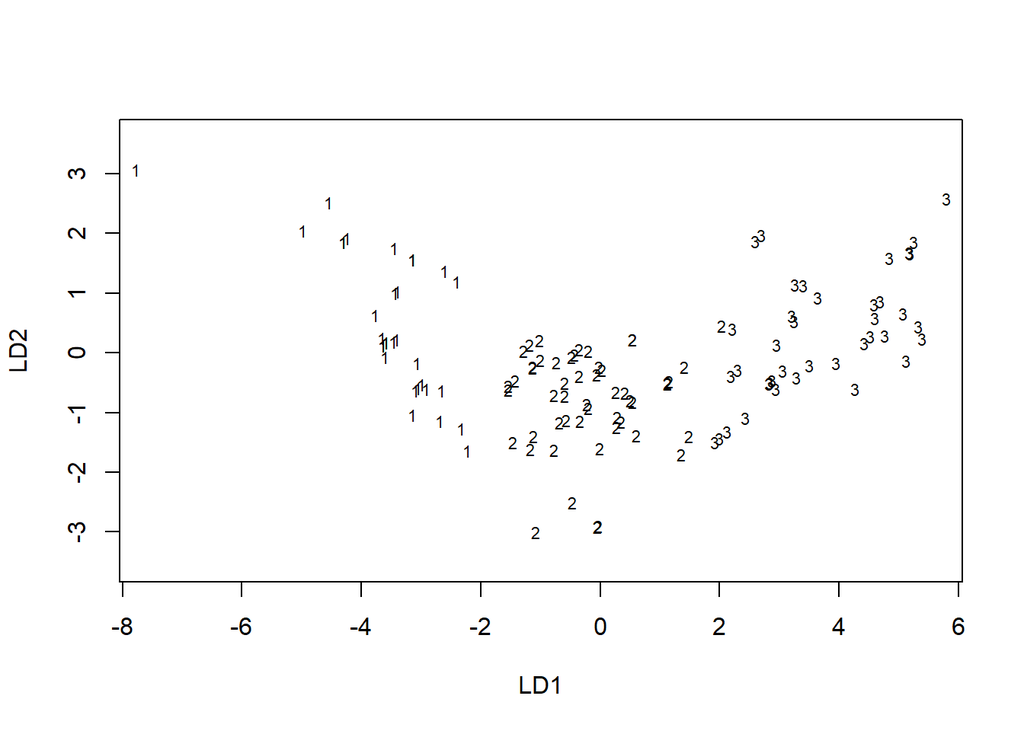

```r
plot(lda.fit)
```

На графике видно четкое разделение на классы, хотя они расположены очень близко друг другу. Мы видим, что данные хорошо разбиваются на классы по значениям LD 1, а вот значения LD 2 для трех классов лежат практически в одном интервале. Это также подтверждают значения доли трассы для двух функций, для LD 1 Proportion of trace значительно больше, чем для LD 2.

Сделаем прогнозы на тестовой выборке:

```r
lda.pred <- predict(lda.fit, data.unknown[,-c(11)])
```

Гистограмма значений первой дискриминантной функции:

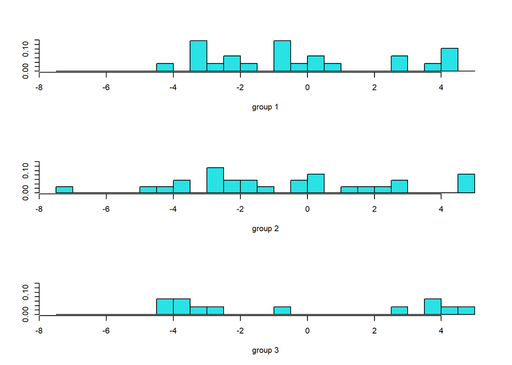

```r
ldahist(data = lda.pred$x[,1], g = cl)
```

И второй:

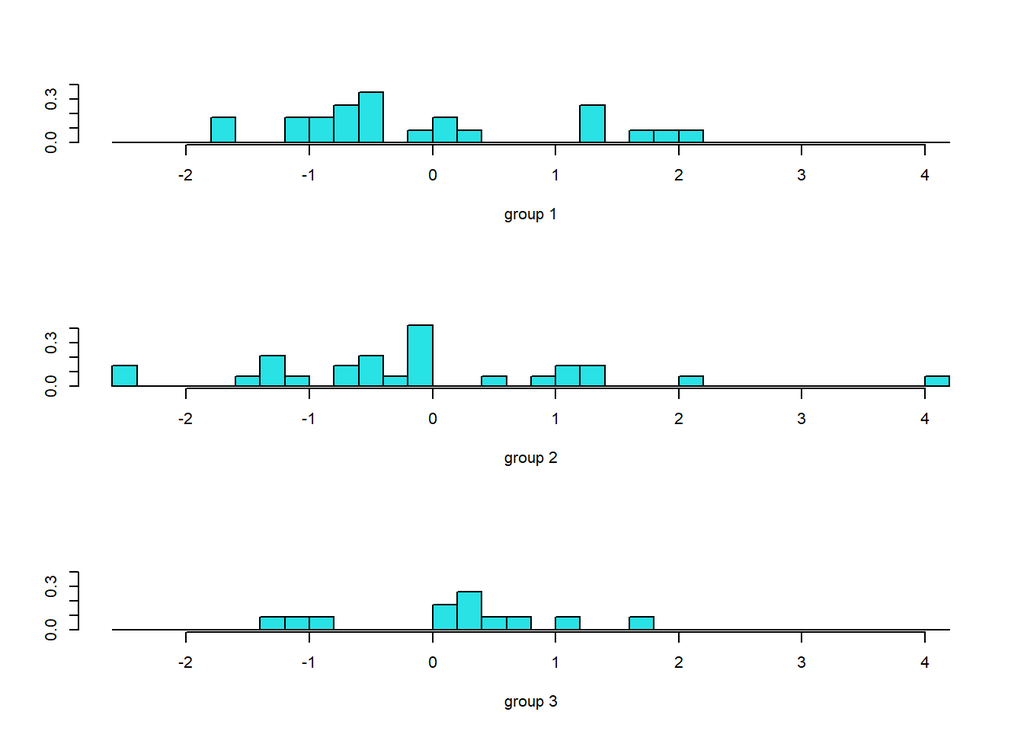

```r
ldahist(data = lda.pred$x[,2], g = cl)
```

Мы видим, что значения дискриминантных функций для разных групп пересекаются. Это может привести к ошибкам в прогнозировании.

Найдем значение Лямбды Уилкса:

```r
ldam <- manova(as.matrix(data.unknown[,-c(11)]) ~ lda.pred$class)

summary(ldam, test = "Wilks")
```

```
##                Df    Wilks approx F num Df den Df    Pr(>F)
## lda.pred$class  2 0.054853   16.349     20    100 < 2.2e-16 ***
## Residuals      59
## ---
## Signif. codes:  0 '***' 0.001 '**' 0.01 '*' 0.05 '.' 0.1 ' ' 1
```

Мы видим, что значение p-value меньше 0,05 , это говорит о том, что на уровне значимости 0,05 разделение на классы при помощи дискриминантного анализа оказывает статистически значимое влияние на наши данные. Значение лямбды-Уилкса - 0,05, что довольно близко к 0, что говорит о качественном разделении на классы.

Также мы получали неплохие результаты разбиения на кластеры при помощи метода Варда. Проведем дискриминантный анализ на основе его результатов.

```r
mahalanobis <- sqrt(D2.dist(cluster_df, cov(cluster_df)))
hclust_w <- hclust(mahalanobis, method = 'ward.D2')
hclust_w$cluster <- cutree(hclust_w, k = 3)
clw <- hclust_w$cluster
cluster_ward <- as.data.frame(cbind(cluster_df, clw))
```

```r
smpl_sizew <- floor(2/3 * nrow(cluster_ward))

set.seed(123)
train_indw <- sample(seq_len(nrow(cluster_ward)), size = smpl_sizew)

data.trainw <- as.data.frame(cluster_ward[train_indw,])
data.unknownw <- as.data.frame(cluster_ward[-train_indw,])
```

```r
ldaw.fit <- lda(data.trainw[,-c(11)], data.trainw$cl)
ldaw.fit
```

```
## Call:
## lda(data.trainw[, -c(11)], data.trainw$cl)
##
## Prior probabilities of groups:
##          1          2          3
## 0.19354839 0.71774194 0.08870968
##
## Group means:
##    wheelbase  carlength   carwidth   carheight curbweight enginesize horsepower
## 1  0.2237858  0.5311051  0.4055206 -0.27880219   0.916866  1.3411800   1.444824
## 2 -0.1972033 -0.2293760 -0.2497047 -0.05250413  -0.408231 -0.4251941  -0.371225
## 3  2.0021515  1.4689165  1.5610337  1.48234795   1.914507  1.1176244   0.117329
##      peakrpm    citympg highwaympg
## 1 -0.2707044 -0.9394208 -0.8891996
## 2  0.2890020  0.2379773  0.2717145
## 3 -1.3666145 -0.3241578 -0.6828018
##
## Coefficients of linear discriminants:
##                   LD1          LD2
## wheelbase   0.8351337 -0.433022361
## carlength  -1.2459946  0.662685192
## carwidth   -0.7490103 -0.708366052
## carheight  -0.3542650 -0.005247092
## curbweight  2.9737603 -1.698385319
## enginesize -0.1733443  0.556861956
## horsepower  0.5257571  2.333129012
## peakrpm    -0.4738483 -0.318226891
## citympg     0.2563184 -1.044766910
## highwaympg  0.1950970  1.322847739
##
## Proportion of trace:
##    LD1    LD2
## 0.5918 0.4082
```

Мы видим, что априорная вероятность для третьего класса очень мала. Это связано с тем, что очень мало объектов 3 класса попали в обучающую выборку. Убедимся в этом, посмотрев на графики.

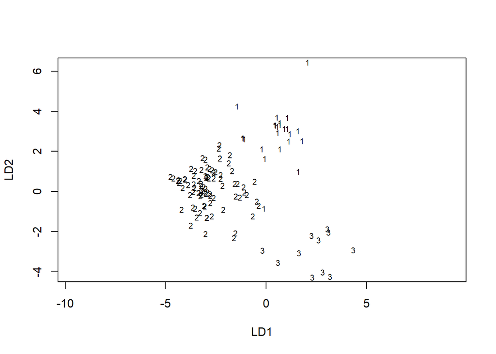

```r
plot(ldaw.fit)
```

В этом случае кластеры также находятся очень близко друг к другу, но теперь их нельзя четко разделить только по значениям LD 1. Об это говорит и доля трассы, которая теперь для LD 1 и LD 2 функций равна 0,6 и 0,4 соответственно.

```r
ldaw.pred <- predict(ldaw.fit, data.unknownw[,-c(11)])
```

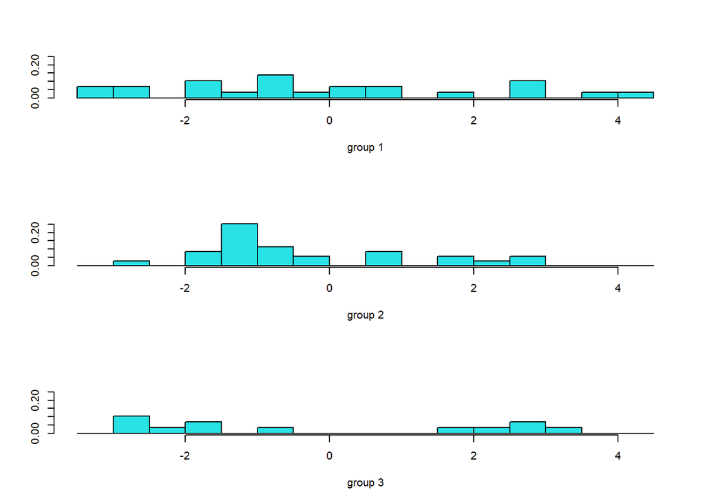

```r
ldahist(data = ldaw.pred$x[,1], g = cl)
```

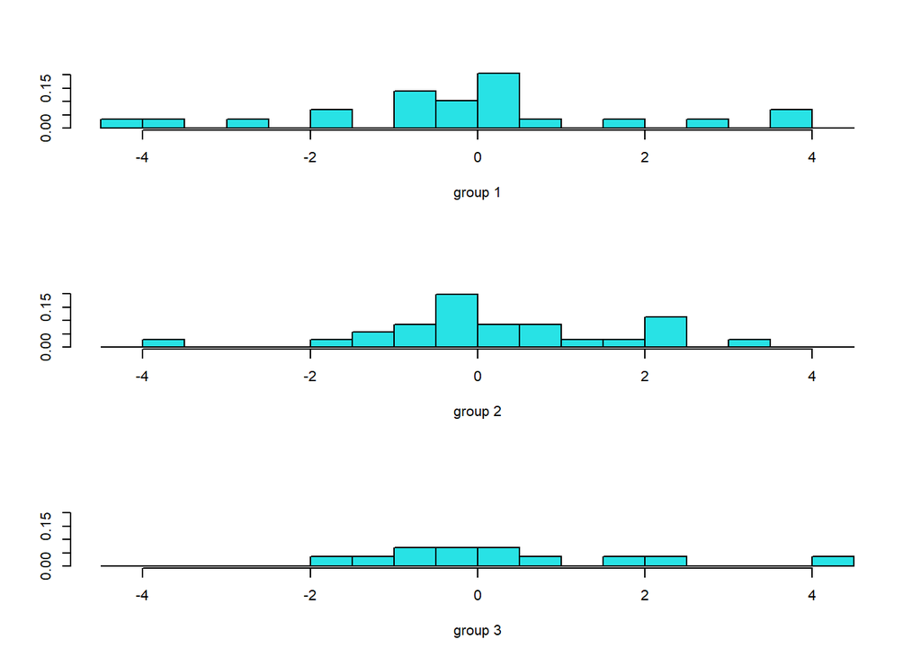

```r
ldahist(data = ldaw.pred$x[,2], g = cl)
```

Мы видим, что значения первой и второй дискриминантных функций пересекаются, что может приводить к ошибкам в предсказании.

```r
ldamw <- manova(as.matrix(data.unknownw[,-c(11)]) ~ ldaw.pred$class)

summary(ldamw, test = "Wilks")
```

```
##                 Df    Wilks approx F num Df den Df    Pr(>F)
## ldaw.pred$class  2 0.051367   17.061     20    100 < 2.2e-16 ***
## Residuals       59
## ---
## Signif. codes:  0 '***' 0.001 '**' 0.01 '*' 0.05 '.' 0.1 ' ' 1
```

В этом случае значение p-value снова меньше 0,05 , это говорит о том, что на уровне значимости 0,05 разделение на классы при помощи дискриминантного анализа на основе метода Варда оказывает статистически значимое влияние на наши данные. Значение лямбды-Уилкса - 0,05, что довольно близко к 0, что говорит о качественном разделении на классы.

#### **6.2. Отнесение новых объектов (3-4 наблюдения) к выделенным и описанным кластерам различными способами с использованием ДФ**

Вернемся к 4 наблюдениям, которые мы выделили перед кластерным анализом.

```r
paged_table(rand_df)
```

|  | wheelbase | carlength | carwidth | carheight | curbweight | enginesize | horsepower | peakrpm | citympg | highwaympg | price |
| --- | --- | --- | --- | --- | --- | --- | --- | --- | --- | --- | --- |
| 79 | 93.7 | 157.3 | 64.4 | 50.8 | 2004 | 92 | 68 | 5500 | 31 | 38 | 6669 |
| 182 | 104.5 | 187.8 | 66.5 | 54.1 | 3151 | 161 | 156 | 5200 | 19 | 24 | 15750 |
| 144 | 97.2 | 172.0 | 65.4 | 52.5 | 2340 | 108 | 94 | 5200 | 26 | 32 | 9960 |
| 177 | 102.4 | 175.6 | 66.5 | 54.9 | 2414 | 122 | 92 | 4200 | 27 | 32 | 10898 |

Удалим целевую переменную и отмасштабируем.

```r
cluster_rand <- as.data.frame(scale(rand_df[, -c(11)]))
paged_table(cluster_rand)
```

|  | wheelbase | carlength | carwidth | carheight | curbweight | enginesize | horsepower | peakrpm | citympg | highwaympg |
| --- | --- | --- | --- | --- | --- | --- | --- | --- | --- | --- |
| 79 | -1.1710333 | -1.26405773 | -1.2871918 | -1.2531377 | -0.9792012 | -0.97457627 | -0.9182333 | 0.8364284 | 1.05175439 | 1.13150476 |
| 182 | 1.0284727 | 1.16452562 | 0.7921180 | 0.5646005 | 1.3940556 | 1.36440678 | 1.4239269 | 0.3081578 | -1.35225564 | -1.30558242 |
| 144 | -0.4582304 | -0.09356018 | -0.2970443 | -0.3167271 | -0.2839839 | -0.43220339 | -0.2262314 | 0.3081578 | 0.05008354 | 0.08703883 |
| 177 | 0.6007910 | 0.19309228 | 0.7921180 | 1.0052643 | -0.1308705 | 0.04237288 | -0.2794623 | -1.4527440 | 0.25041771 | 0.08703883 |

Теперь сделаем прогноз для этих наблюдений при помощи дискриминатных функций построенных на основе метода kmeans.

```r
lda4.pred <- predict(lda.fit, cluster_rand[,-c(11)])
head(lda4.pred)
```

```
## $class
## [1] 1 3 2 2
## Levels: 1 2 3
##
## $posterior
##                1            2            3
## 79  9.965228e-01 3.477204e-03 4.154451e-12
## 182 9.960754e-15 1.967984e-05 9.999803e-01
## 144 6.103964e-03 9.938760e-01 2.005584e-05
## 177 2.973162e-03 9.963241e-01 7.027420e-04
##
## $x
##            LD1        LD2
## 79  -3.7491284  0.2922503
## 182  4.3513838  0.1753950
## 144 -0.9363129 -0.7557766
## 177 -0.3172983  0.2372314
```

Мы получили предсказанные классы для каждого из наблюдений, апостериорные вероятности того, что наблюдение принадлежит к каждому классу, значение дискриминантной функции для каждого наблюдения. . 79 наблюдение относится к 1 классу, 182 - к 3, 144 и 177 - ко 2.

Теперь посмотрим на значения цены для каждого из этих наблюдений.

```r
rand_df[c('price')]
```

```
##     price
## 79   6669
## 182 15750
## 144  9960
## 177 10898
```

79 наблюдение относится к 1 классу (дешевые машины), его цена действительно ниже других; 182 наблюдение принадлежит 3 классу ( дорогие машины), цена этого авто значительно превышает цены остальных; 144 и 177 наблюдения относятся ко 2 классу ( машины средней ценовой категории), и значение переменной price для этих автомобилей находится между значениями цен для 79 и 182. Таким образом, можно сказать, что наша модель достаточно неплохо справилась с задачей классификации.

Классифицируем эти наблюдения при помощи ДФ, построенных на основе метода Варда.

```r
ldaw.pred3 <- predict(ldaw.fit, cluster_rand[,-c(11)])
head(ldaw.pred3)
```

```
## $class
## [1] 2 1 2 2
## Levels: 1 2 3
##
## $posterior
##                1           2            3
## 79  1.951519e-05 0.999980484 7.271147e-10
## 182 9.930892e-01 0.006900884 9.896009e-06
## 144 8.943706e-05 0.999910562 6.758125e-10
## 177 4.758646e-05 0.999952306 1.077993e-07
##
## $x
##           LD1         LD2
## 79  -1.196249 -0.26015047
## 182  2.455360  1.10654287
## 144 -1.005747  0.06932358
## 177 -0.531798 -0.74666100
```

В этом случае 79, 144 и 177 наблюдения были отнесены к одному классу (2), а 182 к 1. Посмотрим на средние по классам аналогично тому, как мы это делали для классов, найденных методом k-средних.

```r
cluster_ward$price <- final_data$price
x1 <- c()
x2 <- c()
x3 <- c()

for (i in  1:186) {
  if (cluster_ward$clw[i] == 1) {
    x1 <- c(x1, cluster_ward$price[i])
  }else if (cluster_ward$clw[i] == 2) {
    x2 <- c(x2, cluster_ward$price[i])
  } else {
    x3 <- c(x3, cluster_ward$price[i])
  }
}

print(mean(x1))
```

```
## [1] 15924.81
```

```r
print(mean(x2))
```

```
## [1] 9557.091
```

```r
print(mean(x3))
```

```
## [1] 17737.38
```

Исходя из значений средних для кластеров, 1 класс - это машины средней ценовой категории, 2 - дешевые авто, 3 - дорогие. Таким образом, мы видим, что наблюдение 182 с ценой 15750 было отнесено к авто средней ценовой категории, а наблюдения 79, 144 и 177, цены которых ниже, к дешевым.

#### **6.3. Уточнение результатов классификации, выполненной с помощью метода к-средних, с помощью аппарата дискриминантного анализа (выявление некорректно классифицированных наблюдений)***

```r
table(data.unknown$cl)
```

```
##
##  1  2  3
## 26 18 18
```

```r
lda.pred$class
```

```
##  [1] 2 2 3 3 3 2 3 1 1 1 1 1 1 1 1 1 1 2 2 1 2 2 3 1 1 3 2 2 1 1 3 3 3 3 3 3 1 2
## [39] 1 3 2 3 1 2 2 2 2 2 2 1 2 1 1 2 2 2 2 2 3 3 2 3
## Levels: 1 2 3
```

```r
table(lda.pred$class, data.unknown[,c("cl")])
```

```
##
##      1  2  3
##   1 21  0  0
##   2  5 18  1
##   3  0  0 17
```

```r
summary(lda.pred$class)
```

```
##  1  2  3
## 21 24 17
```

Мы видим, что наша модель допустила ошибки во время классификации. Так она отнесла 5 объектов ко 2 классу, хотя согласно кластерному анализу они входят в 1 класс, также один из объектов 3 класса она отнесла ко 2.

Выясним, какие это наблюдения.

```r
which(data.unknown$cl != lda.pred$class)
```

```
## [1] 41 44 45 46 54 55
```

Таким образом, наблюдения 41, 44, 45, 46, 54 и 55 являются некорректно классифицированными.

#### **6.4. Анализ классификационной матрицы (classification matrix). Вывод о качестве разбиения объектов на кластеры**

Проанализируем классификационную матрицу по результатам дискриминантного анализа на основе метода k - средних.

```r
misclass <- function(pred, obs) { tbl <- table(pred, obs)
sum <- colSums(tbl)
dia <- diag(tbl)
msc <- ((sum - dia)/sum) * 100
m.m <- mean(msc)
cat("Classification table:", "\n")
print(tbl)
cat("Misclassification errors:", "\n")
print(round(msc, 2))

print(round(m.m, 2))}

misclass(lda.pred$class, data.unknown[,c("cl")])
```

```
## Classification table:
##     obs
## pred  1  2  3
##    1 21  0  0
##    2  5 18  1
##    3  0  0 17
## Misclassification errors:
##     1     2     3
## 19.23  0.00  5.56
## [1] 8.26
```

Посмотрим на аналогичную матрицу, но уже для дискриминантной модели, построенной на основе метода Варда.

```r
misclass <- function(pred, obs) { tbl <- table(pred, obs)
sum <- colSums(tbl)
dia <- diag(tbl)
msc <- ((sum - dia)/sum) * 100
m.m <- mean(msc)
cat("Classification table:", "\n")
print(tbl)
cat("Misclassification errors:", "\n")
print(round(msc, 2))

print(round(m.m, 2))}

misclass(ldaw.pred$class, data.unknownw[,c("clw")])
```

```
## Classification table:
##     obs
## pred  1  2  3
##    1 13  1  0
##    2  0 43  0
##    3  0  0  5
## Misclassification errors:
##    1    2    3
## 0.00 2.27 0.00
## [1] 0.76
```